# 04 · 机器学习与可视化 Cheat Sheet

**scikit-learn 为主，包含决策树、随机森林、梯度提升树，以及可选 XGBoost。** 沿用之前的阅读方式：**先 `display(df)` 输入样例 → 要预测什么 → 训练/验证/测试 → 指标与预测表 → `plt.*` 图 → 中文解读。**

每例数据单独生成，每例导入自己需要的 sklearn 类；只需先运行本册初始化，之后可以任选案例独立执行。 表格预览前8–9行，输出中标出总行数；机器学习需要比手算回测更多的样本，因此示例使用约140–270行合成数据。

**复制方法：** 已有自己的 `df` 时，跳过示例建表格，先 `display(df.head(8))`，对齐字段与信息时点，再复制训练和绘图格。 `features` 必须显式列出，不能用“除了目标之外全选”将未来收益、标签实现时间或事后信息混进模型。

## 按问题找案例

| 问题 | 案例 |
| --- | --- |
| 只有价格，怎样构造特征和未来标签？ | M01 因果特征、label_end、隔离边界 |
| 连续数值预测先做什么？ | M02 LinearRegression + DummyRegressor |
| 缺失值、量纲差异和共线性？ | M03 Pipeline + Imputer + Scaler + Ridge；附 ElasticNet 替换 |
| 数值列和类别列混合？ | M04 ColumnTransformer + OneHotEncoder |
| 预测涨跌，怎样看分类结果？ | M05 LogisticRegression + 混淆矩阵 |
| 正类很少，概率阈值怎么选？ | M06 验证集选阈值 + PR 曲线 |
| 一棵树有多深才合适？ | M07 DecisionTreeRegressor 过拟合图 |
| 想拟合非线性和特征交互？ | M08 RandomForestRegressor |
| 不额外装包的提升树？ | M09 HistGradientBoostingRegressor |
| 想用 XGBoost 和 early stopping？ | M10 可选 XGBRegressor |
| 怎样在时间序列中搜索参数？ | M11 TimeSeriesSplit + GridSearchCV |
| 多资产面板怎样滚动训练？ | M12 按日期 Walk-forward + 标签到期检查 |
| 特征是否真的帮助这个模型？ | M13 验证集置换重要性 |
| 想知道预测错在哪里？ | M14 残差 + Rank IC + 基准误差 |
| 特征太相关，想降维？ | M15 训练期拟合 PCA |
| 预测怎样接到策略与回测？ | M16 样本外预测 → 仓位 → 扣费净值 |

## 依赖与版本

基础部分需要 NumPy、pandas、Matplotlib、scikit-learn；不需要网络数据、API key 或GPU。 Python 3.8 参考版本为 **scikit-learn 1.3.2**。XGBoost 是 M10 的可选依赖；没有安装时该例会明确输出跳过提示，其余例子照常运行。

```
# Python 3.8：先安装仓库的基础依赖
python -m pip install -r requirements-py38.txt
# 可选：运行 M10
python -m pip install -r requirements-xgboost-py38.txt
```

较新 Python 使用 `requirements.txt`，可选 XGBoost 使用 `requirements-xgboost.txt`。 在 Jupyter 中可以用 `%pip install ...` 安装到当前 kernel 对应环境，安装后重启 kernel；代码格不会自动安装任何包。 macOS 若提示缺 `libomp.dylib`，需配置 OpenMP 运行库（例如已使用 Homebrew 的环境可 `brew install libomp`），再重启 kernel。

| 常见兼容点 | 本册写法 |
| --- | --- |
| 新版本 RMSE API 改动 | `np.sqrt(mean_squared_error(y, pred))` |
| OneHotEncoder 参数名 | sklearn ≥1.2 用 `sparse_output=False`；更早版本对应 `sparse=False` |
| XGBoost early stopping 参数位置 | 放在 `XGBRegressor(...)` 构造器内，验证集放在 `eval_set` 最后 |
| 随机内部验证不适合时间任务 | HistGradientBoosting 明确设置 `early_stopping=False`；需要选迭代数时另做时间验证 |

## 先确认信息时点

多数案例假定 **盘前特征 → 当天开盘至收盘收益**，所以按完整日期排序切分即可；不需要在已对齐的数据上再乱加 shift。 M01 / M11 / M12 则是 **收盘后的特征 → 随后若干期收益**，额外记录 `label_end`，训练时剔除当时尚不可知的标签。 普通随机 `train_test_split` 不适合这里的未来预测目的；多资产同日的样本应一起切分。

模型都用合成数据解释 API 和研究流程。人为设置的信号强度、测试指标和净值**不能证明真实行情可预测或策略盈利**。 日期用普通业务日生成，只代表教学采样顺序，不是实际交易所日历。

```python
# SETUP：只需一次。每个案例的训练格再导入所需 sklearn 类。
import numpy as np
import pandas as pd
import matplotlib.pyplot as plt
from IPython.display import display
import sklearn

print('scikit-learn:', sklearn.__version__)
BLUE, TEAL, RED, ORANGE = '#2563EB', '#0F766E', '#DC2626', '#D97706'
plt.rcdefaults()
plt.rcParams.update({
    'font.family': 'DejaVu Sans', 'font.size': 10,
    'figure.dpi': 120, 'savefig.dpi': 180,
    'axes.spines.top': False, 'axes.spines.right': False,
    'axes.grid': True, 'axes.grid.axis': 'y', 'axes.axisbelow': True,
    'grid.color': '#E2E8F0', 'grid.alpha': 0.75,
    'axes.titlelocation': 'left', 'axes.titleweight': 'bold',
    'axes.titlesize': 13, 'axes.titlepad': 14,
    'lines.linewidth': 2, 'legend.frameon': False,
})
```

```
scikit-learn: 1.3.2
```

## M01 · 价格表 → 因果特征、未来标签与隔离边界

**先看输入 DataFrame：** 以下是实际参与此例计算的数据预览。

```python
rng = np.random.RandomState(101)
n = 140
df = pd.DataFrame({
    "date": pd.bdate_range("2024-01-02", periods=n),
    "close": 100 * np.cumprod(1 + rng.normal(0.0002, 0.012, n)),
})
print("输入行数：", len(df))
display(df.head(8).round(4))
```

```
输入行数： 140
```

|  | date | close |
| --- | --- | --- |
| 0 | 2024-01-02 | 103.2682 |
| 1 | 2024-01-03 | 104.0673 |
| 2 | 2024-01-04 | 105.2220 |
| 3 | 2024-01-05 | 105.8792 |
| 4 | 2024-01-08 | 106.7276 |
| 5 | 2024-01-09 | 106.3400 |
| 6 | 2024-01-10 | 105.2791 |
| 7 | 2024-01-11 | 106.0657 |

**场景 / 要做什么：**

场景：只有每日收盘价，要预测下一段 close-to-close 收益。date 是交易日，close 是收盘价。假定每天 16:00 收盘信息齐备后生成特征：当天收益、过去5期均值、过去10期波动率。feature_time 记录预测时点，label_end 记录标签全部实现的时点。先构造标签，再按时间切分；训练标签必须严格早于测试首次预测时点，因此边界处至少有一条样本被隔离。最后用训练收益均值建立最简单的基线。

**示例代码：** 明确选择特征，先切分再拟合，最后展示结果。

```python
from sklearn.dummy import DummyRegressor
from sklearn.metrics import mean_absolute_error, mean_squared_error

df["date"] = pd.to_datetime(df["date"])
df = df.sort_values("date").reset_index(drop=True)
assert df["date"].is_unique and (df["close"] > 0).all()
df["feature_time"] = df["date"] + pd.Timedelta(hours=16)
df["ret_1"] = df["close"].pct_change(fill_method=None)
# 收盘后预测，允许使用今天已经实现的收益；rolling 不使用未来行。
df["mean_5"] = df["ret_1"].rolling(5, min_periods=5).mean()
df["vol_10"] = df["ret_1"].rolling(10, min_periods=10).std()
df["target"] = df["close"].shift(-1) / df["close"] - 1
df["label_end"] = df["feature_time"].shift(-1)
features = ["ret_1", "mean_5", "vol_10"]
# 前10行窗口不足；最后1行没有未来标签。只删除，不能把标签填成0。
data = df.dropna(subset=features + ["target", "label_end"]).copy()
display(data[["feature_time"] + features + ["target", "label_end"]].head(8))

test_start = data["feature_time"].iloc[int(len(data) * 0.7)]
train = data.loc[data["label_end"] < test_start].copy()
test = data.loc[data["feature_time"] >= test_start].copy()
purged = data.loc[(data["feature_time"] < test_start) & (data["label_end"] >= test_start)]
assert train["label_end"].max() < test["feature_time"].min()
baseline = DummyRegressor(strategy="mean")
baseline.fit(train[features], train["target"])
test["prediction"] = baseline.predict(test[features])
display(pd.DataFrame({
    "split": ["train", "purged", "test"],
    "rows": [len(train), len(purged), len(test)],
    "first_prediction": [x["feature_time"].min() for x in [train, purged, test]],
    "last_label_end": [x["label_end"].max() for x in [train, purged, test]],
}))
display(test[["feature_time", "target", "prediction"]].head(8))
display(pd.DataFrame({"MAE": [mean_absolute_error(test["target"], test["prediction"])],
                      "RMSE": [np.sqrt(mean_squared_error(test["target"], test["prediction"]))]}))
```

|  | feature_time | ret_1 | mean_5 | vol_10 | target | label_end |
| --- | --- | --- | --- | --- | --- | --- |
| 10 | 2024-01-16 16:00:00 | 0.006546 | -0.002179 | 0.011168 | -0.006868 | 2024-01-17 16:00:00 |
| 11 | 2024-01-17 16:00:00 | -0.006868 | -0.001557 | 0.011268 | 0.002464 | 2024-01-18 16:00:00 |
| 12 | 2024-01-18 16:00:00 | 0.002464 | -0.002559 | 0.010672 | -0.008906 | 2024-01-19 16:00:00 |
| 13 | 2024-01-19 16:00:00 | -0.008906 | 0.000463 | 0.010689 | -0.010999 | 2024-01-22 16:00:00 |
| 14 | 2024-01-22 16:00:00 | -0.010999 | -0.003553 | 0.010400 | 0.011661 | 2024-01-23 16:00:00 |
| 15 | 2024-01-23 16:00:00 | 0.011661 | -0.002530 | 0.011507 | 0.002490 | 2024-01-24 16:00:00 |
| 16 | 2024-01-24 16:00:00 | 0.002490 | -0.000658 | 0.011262 | 0.023945 | 2024-01-25 16:00:00 |
| 17 | 2024-01-25 16:00:00 | 0.023945 | 0.003638 | 0.013615 | 0.031472 | 2024-01-26 16:00:00 |

|  | split | rows | first_prediction | last_label_end |
| --- | --- | --- | --- | --- |
| 0 | train | 89 | 2024-01-16 16:00:00 | 2024-05-20 16:00:00 |
| 1 | purged | 1 | 2024-05-20 16:00:00 | 2024-05-21 16:00:00 |
| 2 | test | 39 | 2024-05-21 16:00:00 | 2024-07-15 16:00:00 |

|  | feature_time | target | prediction |
| --- | --- | --- | --- |
| 100 | 2024-05-21 16:00:00 | -0.013189 | 0.001892 |
| 101 | 2024-05-22 16:00:00 | -0.016425 | 0.001892 |
| 102 | 2024-05-23 16:00:00 | -0.015756 | 0.001892 |
| 103 | 2024-05-24 16:00:00 | 0.000698 | 0.001892 |
| 104 | 2024-05-27 16:00:00 | -0.004733 | 0.001892 |
| 105 | 2024-05-28 16:00:00 | -0.009056 | 0.001892 |
| 106 | 2024-05-29 16:00:00 | 0.001526 | 0.001892 |
| 107 | 2024-05-30 16:00:00 | -0.009456 | 0.001892 |

|  | MAE | RMSE |
| --- | --- | --- |
| 0 | 0.008762 | 0.0113 |

**可视化：** 使用刚刚计算出的指标和预测。

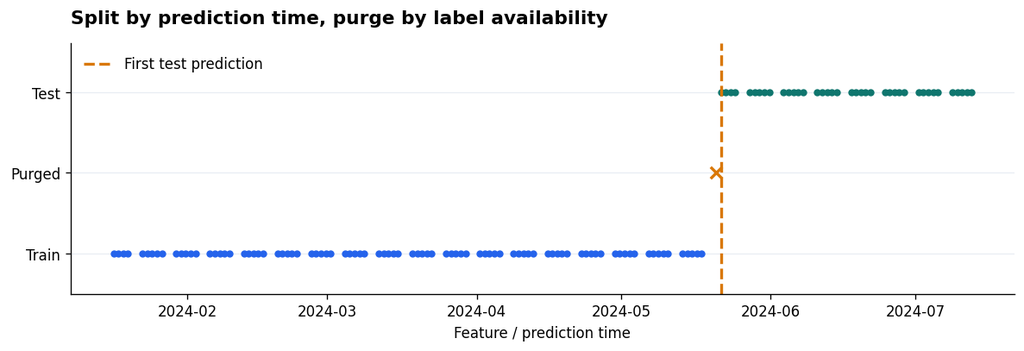

```python
plt.figure(figsize=(10, 3.5))
plt.scatter(train["feature_time"], np.zeros(len(train)), color=BLUE, s=16)
plt.scatter(purged["feature_time"], np.ones(len(purged)), color=ORANGE, s=65, marker="x")
plt.scatter(test["feature_time"], np.full(len(test), 2), color=TEAL, s=16)
plt.axvline(test_start, color=ORANGE, linestyle="--", label="First test prediction")
plt.yticks([0, 1, 2], ["Train", "Purged", "Test"])
plt.ylim(-0.5, 2.6)
plt.title("Split by prediction time, purge by label availability")
plt.xlabel("Feature / prediction time")
plt.legend(loc="upper left")
plt.tight_layout()
plt.show()
```

**怎么看：** 先看加工后的表：每一行特征都只用截至 feature_time 的价格，而 target 会用到 label_end 的价格。橙色叉号表示训练标签在测试开始时尚未严格落在过去；本例将其隔离。基线的预测值是训练集 target 的均值，不会从测试期更新。

**换数据时注意：** 本例是预测任务，不是可成交回测。收盘后得到信号，通常不能再按同一收盘价成交；接回测时应改成下一开盘执行并重新对齐收益。这里采用 label_end < test_start 的保守边界；若多期标签跨越更多交易日，应继续按真实 label_end 隔离，不能只固定删1行。140行合成数据只用于展示流程。

## M02 · 线性回归：对比训练集均值基线

**先看输入 DataFrame：** 以下是实际参与此例计算的数据预览。

```python
rng = np.random.RandomState(102)
n = 150
flow_z = rng.normal(size=n)
overnight_ret = rng.normal(0, 0.008, n)
prev_ret = rng.normal(0, 0.01, n)
df = pd.DataFrame({
    "date": pd.bdate_range("2024-01-02", periods=n),
    "flow_z": flow_z,
    "overnight_ret": overnight_ret,
    "prev_ret": prev_ret,
    "intraday_ret": 0.0025 * flow_z + 0.18 * overnight_ret - 0.08 * prev_ret + rng.normal(0, 0.006, n),
})
print("输入行数：", len(df))
display(df.head(8).round(5))
```

```
输入行数： 150
```

|  | date | flow_z | overnight_ret | prev_ret | intraday_ret |
| --- | --- | --- | --- | --- | --- |
| 0 | 2024-01-02 | 1.66807 | 0.00605 | 0.00017 | 0.01582 |
| 1 | 2024-01-03 | 0.92586 | -0.00101 | 0.01352 | -0.00197 |
| 2 | 2024-01-04 | 1.05800 | 0.00756 | 0.00230 | 0.00309 |
| 3 | 2024-01-05 | -0.92034 | 0.00683 | 0.00373 | 0.00082 |
| 4 | 2024-01-08 | 1.29975 | -0.01417 | 0.00955 | 0.00178 |
| 5 | 2024-01-09 | 0.33118 | 0.00959 | 0.00329 | -0.00640 |
| 6 | 2024-01-10 | -0.50984 | -0.01047 | 0.00236 | -0.00114 |
| 7 | 2024-01-11 | -0.90310 | 0.01052 | 0.00387 | 0.00632 |

**场景 / 要做什么：**

场景：使用盘前信息预测当天开盘到收盘收益。flow_z 是事先定义的盘前订单流分数，overnight_ret 是昨收至09:25盘前报价的收益，prev_ret 是上一交易日已实现收益；三者在当天09:25已知。intraday_ret 是当天开盘到收盘收益，直到收盘才完整已知。按日期前70%训练、后30%测试；比较 LinearRegression 与只预测训练均值的 DummyRegressor，展示 MAE、RMSE、R²。

**示例代码：** 明确选择特征，先切分再拟合，最后展示结果。

```python
from sklearn.linear_model import LinearRegression
from sklearn.dummy import DummyRegressor
from sklearn.metrics import mean_absolute_error, mean_squared_error, r2_score

df["date"] = pd.to_datetime(df["date"])
df = df.sort_values("date").reset_index(drop=True)
assert df["date"].is_unique
features = ["flow_z", "overnight_ret", "prev_ret"]
split = int(len(df) * 0.7)
train, test = df.iloc[:split].copy(), df.iloc[split:].copy()
assert train["date"].max() < test["date"].min()
X_train, y_train = train[features], train["intraday_ret"]
X_test, y_test = test[features], test["intraday_ret"]
model = LinearRegression()
baseline = DummyRegressor(strategy="mean")
model.fit(X_train, y_train)
baseline.fit(X_train, y_train)
test["prediction"] = model.predict(X_test)
test["baseline"] = baseline.predict(X_test)
metrics = []
for name in ["prediction", "baseline"]:
    metrics.append({"model": name,
                    "MAE": mean_absolute_error(y_test, test[name]),
                    "RMSE": np.sqrt(mean_squared_error(y_test, test[name])),
                    "R2": r2_score(y_test, test[name]) if y_test.nunique() > 1 else np.nan})
display(pd.DataFrame(metrics).set_index("model").round(5))
display(test[["date", "intraday_ret", "prediction", "baseline"]].head(8).round(5))
```

| model | MAE | RMSE | R2 |
| --- | --- | --- | --- |
| prediction | 0.00514 | 0.00616 | 0.13655 |
| baseline | 0.00553 | 0.00663 | -0.00097 |

|  | date | intraday_ret | prediction | baseline |
| --- | --- | --- | --- | --- |
| 105 | 2024-05-28 | -0.00889 | -0.00076 | 0.00065 |
| 106 | 2024-05-29 | -0.00327 | 0.00167 | 0.00065 |
| 107 | 2024-05-30 | 0.01234 | 0.00265 | 0.00065 |
| 108 | 2024-05-31 | -0.00666 | -0.00653 | 0.00065 |
| 109 | 2024-06-03 | -0.00298 | -0.00063 | 0.00065 |
| 110 | 2024-06-04 | -0.00081 | -0.00024 | 0.00065 |
| 111 | 2024-06-05 | 0.00440 | 0.00276 | 0.00065 |
| 112 | 2024-06-06 | -0.00577 | 0.00211 | 0.00065 |

**可视化：** 使用刚刚计算出的指标和预测。

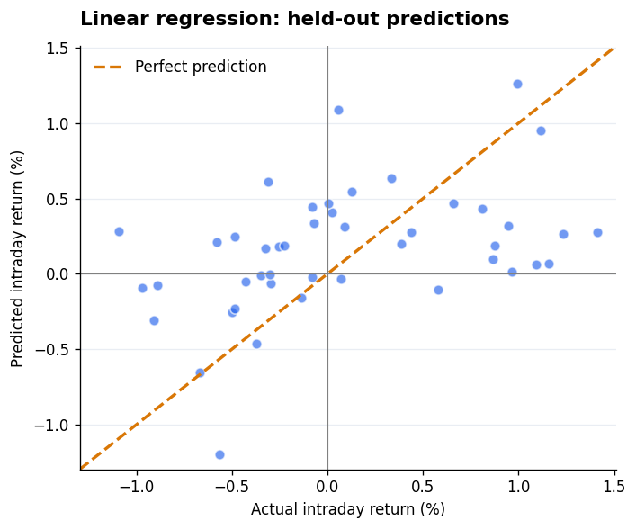

```python
actual_pct = test["intraday_ret"] * 100
pred_pct = test["prediction"] * 100
lower = min(actual_pct.min(), pred_pct.min()) - 0.1
upper = max(actual_pct.max(), pred_pct.max()) + 0.1
plt.figure(figsize=(6, 5))
plt.scatter(actual_pct, pred_pct, color=BLUE, alpha=0.65, edgecolors="white", s=45)
plt.plot([lower, upper], [lower, upper], color=ORANGE, linestyle="--", label="Perfect prediction")
plt.xlim(lower, upper)
plt.ylim(lower, upper)
plt.axhline(0, color="grey", linewidth=0.7)
plt.axvline(0, color="grey", linewidth=0.7)
plt.title("Linear regression: held-out predictions")
plt.xlabel("Actual intraday return (%)")
plt.ylabel("Predicted intraday return (%)")
plt.legend()
plt.tight_layout()
plt.show()
```

**怎么看：** 散点越接近对角线，预测误差越小；集中在水平线附近说明模型给出的预测变化有限。先检查模型的 MAE/RMSE 是否比训练均值基线更低，再看 R²。R²可以为负；其参照的分母使用测试目标相对测试均值的平方差，并不等同于表里的训练均值基线。

**换数据时注意：** 收益使用小数存储，绘图乘100后是百分比。这里模拟了微弱线性关系，不能据此推断真实可预测性。不要预测价格水平后用高R²宣称策略有效，也不要根据测试结果反复选特征。若同一天有多资产，应按完整日期切分，不能在同一天中间切行。

## M03 · 缺失值与量纲不同：Imputer → Scaler → Ridge

**先看输入 DataFrame：** 以下是实际参与此例计算的数据预览。

```python
rng = np.random.RandomState(103)
n = 150
order_flow = rng.normal(0, 1000, n)
prev_ret = rng.normal(0, 0.012, n)
past_vol = rng.uniform(0.008, 0.03, n)
df = pd.DataFrame({
    "date": pd.bdate_range("2024-01-02", periods=n),
    "order_flow": order_flow,
    "prev_ret": prev_ret,
    "past_vol": past_vol,
    "intraday_ret": 0.000002 * order_flow - 0.12 * prev_ret + 0.08 * (past_vol - 0.02) + rng.normal(0, 0.006, n),
})
# 模拟特征缺失；标签仍完整，不填充或伪造标签。
df.loc[rng.choice(n, 15, replace=False), "order_flow"] = np.nan
df.loc[rng.choice(n, 12, replace=False), "past_vol"] = np.nan
print("输入行数：", len(df))
display(df.head(8).round(5))
```

```
输入行数： 150
```

|  | date | order_flow | prev_ret | past_vol | intraday_ret |
| --- | --- | --- | --- | --- | --- |
| 0 | 2024-01-02 | -1249.27835 | 0.00015 | 0.02938 | 0.00836 |
| 1 | 2024-01-03 | NaN | -0.00101 | 0.00831 | -0.00579 |
| 2 | 2024-01-04 | 383.79330 | 0.01971 | 0.01965 | -0.00374 |
| 3 | 2024-01-05 | -385.46147 | -0.01211 | 0.01046 | 0.00033 |
| 4 | 2024-01-08 | -1085.13673 | -0.00930 | 0.01272 | 0.00427 |
| 5 | 2024-01-09 | 2327.21902 | 0.00648 | 0.01348 | 0.00967 |
| 6 | 2024-01-10 | 430.79295 | -0.00299 | 0.00903 | -0.00000 |
| 7 | 2024-01-11 | 432.31577 | 0.00603 | 0.01607 | 0.00636 |

**场景 / 要做什么：**

场景：数值特征有缺失、单位不同，希望建立稳定的线性基线。order_flow 是盘前流量，prev_ret 是昨日收益，past_vol 是截至昨日的波动率，全部在当天开盘前可用；intraday_ret 是当天开盘至收盘收益。前70%训练、后30%测试。在 Pipeline 内用训练数据拟合中位数填充、标准化与 Ridge，避免先对全量数据做预处理。alpha=1.0 事先固定。

**示例代码：** 明确选择特征，先切分再拟合，最后展示结果。

```python
from sklearn.pipeline import Pipeline
from sklearn.impute import SimpleImputer
from sklearn.preprocessing import StandardScaler
from sklearn.linear_model import Ridge
from sklearn.dummy import DummyRegressor
from sklearn.metrics import mean_absolute_error, mean_squared_error

df["date"] = pd.to_datetime(df["date"])
df = df.sort_values("date").reset_index(drop=True)
features = ["order_flow", "prev_ret", "past_vol"]
split = int(len(df) * 0.7)
train, test = df.iloc[:split].copy(), df.iloc[split:].copy()
assert train["date"].max() < test["date"].min()
assert train[features].notna().any().all(), "训练期整列为空时应删除或另行定义该特征"
assert df["intraday_ret"].notna().all()
model = Pipeline([
    ("imputer", SimpleImputer(strategy="median")),
    ("scaler", StandardScaler()),
    ("ridge", Ridge(alpha=1.0)),
])
model.fit(train[features], train["intraday_ret"])
test["prediction"] = model.predict(test[features])
baseline = DummyRegressor(strategy="mean").fit(train[features], train["intraday_ret"])
test["baseline"] = baseline.predict(test[features])
display(pd.DataFrame({"train_missing": train[features].isna().sum(),
                      "test_missing": test[features].isna().sum(),
                      "train_median": model.named_steps["imputer"].statistics_}, index=features))
display(pd.DataFrame([
    {"model": c, "MAE": mean_absolute_error(test["intraday_ret"], test[c]),
     "RMSE": np.sqrt(mean_squared_error(test["intraday_ret"], test[c]))}
    for c in ["prediction", "baseline"]
]).set_index("model").round(5))
display(test[["date", "intraday_ret", "prediction"]].head(8).round(5))
coef = pd.Series(model.named_steps["ridge"].coef_, index=features).sort_values()
display(coef.to_frame("coefficient_per_training_std"))
```

|  | train_missing | test_missing | train_median |
| --- | --- | --- | --- |
| order_flow | 10 | 5 | 81.666853 |
| prev_ret | 0 | 0 | -0.001646 |
| past_vol | 9 | 3 | 0.020201 |

| model | MAE | RMSE |
| --- | --- | --- |
| prediction | 0.00492 | 0.00611 |
| baseline | 0.00541 | 0.00663 |

|  | date | intraday_ret | prediction |
| --- | --- | --- | --- |
| 105 | 2024-05-28 | -0.00214 | 0.00226 |
| 106 | 2024-05-29 | -0.00428 | -0.00133 |
| 107 | 2024-05-30 | -0.01410 | -0.00713 |
| 108 | 2024-05-31 | 0.00000 | 0.00347 |
| 109 | 2024-06-03 | 0.00281 | 0.00222 |
| 110 | 2024-06-04 | 0.00972 | 0.00632 |
| 111 | 2024-06-05 | -0.00518 | -0.00423 |
| 112 | 2024-06-06 | -0.00533 | 0.00075 |

|  | coefficient_per_training_std |
| --- | --- |
| prev_ret | -0.002979 |
| past_vol | 0.000180 |
| order_flow | 0.002414 |

**可视化：** 使用刚刚计算出的指标和预测。

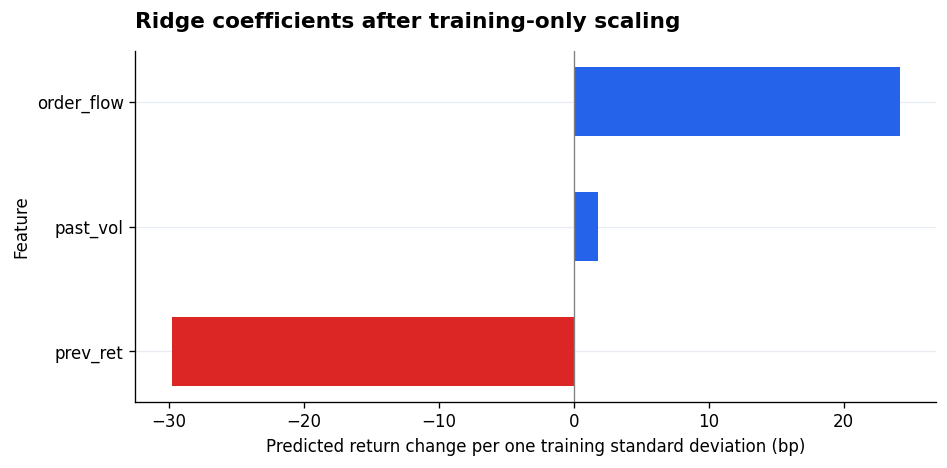

```python
plt.figure(figsize=(8, 4))
plt.barh(coef.index, coef * 10000, color=np.where(coef >= 0, BLUE, RED), height=0.55)
plt.axvline(0, color="grey", linewidth=0.8)
plt.title("Ridge coefficients after training-only scaling")
plt.xlabel("Predicted return change per one training standard deviation (bp)")
plt.ylabel("Feature")
plt.tight_layout()
plt.show()
```

**怎么看：** 中位数表可以直接核对填充值是否只来自训练段。系数图表示其他特征不变时，填充后的某特征提高一个训练期标准差，预测收益变化多少bp；1bp=0.0001。若要换成 ElasticNet，可导入 ElasticNet 后将最后一步替换为 ('ridge', ElasticNet(alpha=0.0001, l1_ratio=0.5, max_iter=10000))；保留步骤名是为了沿用下方取系数代码。参数只是演示，正式调参应在训练期内部做时间验证。

**换数据时注意：** 不能在切分前执行 fit_transform，也不能对测试期重新 fit。标准化系数不等于因果效应，相关特征会分摊系数。示例只有150行；真实数据中缺失本身可能有信息，可另设缺失指示列。若标签缺失，应排除无法评估的行，不能用中位数填充收益标签。

## M04 · 数值＋类别列：ColumnTransformer 与未知类别

**先看输入 DataFrame：** 以下是实际参与此例计算的数据预览。

```python
rng = np.random.RandomState(104)
n = 150
event_type = rng.choice(["normal", "earnings", "macro"], size=n).astype(object)
event_type[120::3] = "special"  # 只在测试期出现的新品类。
flow_z = rng.normal(size=n)
prev_ret = rng.normal(0, 0.012, n)
event_effect = pd.Series(event_type).map({"normal": 0, "earnings": 0.002, "macro": -0.001, "special": 0.003}).to_numpy()
df = pd.DataFrame({
    "date": pd.bdate_range("2024-01-02", periods=n),
    "flow_z": flow_z,
    "prev_ret": prev_ret,
    "event_type": event_type,
    "intraday_ret": 0.002 * flow_z - 0.08 * prev_ret + event_effect + rng.normal(0, 0.005, n),
})
df.loc[[4, 30, 70, 110], "flow_z"] = np.nan
df.loc[[7, 35, 80, 115], "event_type"] = np.nan
print("输入行数：", len(df))
display(df.head(8).round(5))
```

```
输入行数： 150
```

|  | date | flow_z | prev_ret | event_type | intraday_ret |
| --- | --- | --- | --- | --- | --- |
| 0 | 2024-01-02 | 0.19959 | -0.00885 | earnings | 0.00061 |
| 1 | 2024-01-03 | -0.08458 | -0.00145 | earnings | 0.00248 |
| 2 | 2024-01-04 | 0.45411 | -0.00157 | earnings | 0.00735 |
| 3 | 2024-01-05 | -0.86454 | -0.01884 | macro | -0.00604 |
| 4 | 2024-01-08 | NaN | -0.00476 | macro | 0.00619 |
| 5 | 2024-01-09 | -1.01355 | -0.00305 | normal | -0.00613 |
| 6 | 2024-01-10 | 0.36409 | -0.02154 | normal | -0.00930 |
| 7 | 2024-01-11 | -0.26416 | -0.02165 | NaN | 0.00981 |

**场景 / 要做什么：**

场景：盘前数值特征与已预告事件类别混在同一个表中，测试期还出现新品类。flow_z、prev_ret 和 event_type 均在当天开盘前已知；event_type 只能使用当时已知的日程，不能事后按收益贴标签。intraday_ret 是当天开盘至收盘收益。数值列做中位数填充和标准化，类别列做众数填充和 one-hot；日期和目标明确不进入模型。

**示例代码：** 明确选择特征，先切分再拟合，最后展示结果。

```python
from sklearn.compose import ColumnTransformer
from sklearn.pipeline import Pipeline
from sklearn.impute import SimpleImputer
from sklearn.preprocessing import StandardScaler, OneHotEncoder
from sklearn.linear_model import Ridge
from sklearn.dummy import DummyRegressor
from sklearn.metrics import mean_squared_error

df["date"] = pd.to_datetime(df["date"])
df = df.sort_values("date").reset_index(drop=True)
numeric = ["flow_z", "prev_ret"]
categorical = ["event_type"]
features = numeric + categorical
split = int(len(df) * 0.7)
train, test = df.iloc[:split].copy(), df.iloc[split:].copy()
assert train["date"].max() < test["date"].min()
numeric_steps = Pipeline([("imputer", SimpleImputer(strategy="median")),
                          ("scaler", StandardScaler())])
category_steps = Pipeline([("imputer", SimpleImputer(strategy="most_frequent")),
                           ("onehot", OneHotEncoder(handle_unknown="ignore", sparse_output=False))])
# sparse_output=False 需要 sklearn >= 1.2；老版本对应参数名 sparse=False。
preprocess = ColumnTransformer([("num", numeric_steps, numeric),
                                ("cat", category_steps, categorical)], remainder="drop")
model = Pipeline([("preprocess", preprocess), ("ridge", Ridge(alpha=1.0))])
model.fit(train[features], train["intraday_ret"])
test["prediction"] = model.predict(test[features])
baseline = DummyRegressor(strategy="mean").fit(train[numeric], train["intraday_ret"])
test["baseline"] = baseline.predict(test[numeric])
seen = set(train["event_type"].dropna().unique())
unseen = set(test["event_type"].dropna().unique()) - seen
print("训练期出现的类别：", sorted(seen))
print("测试期新增的类别：", sorted(unseen))
display(pd.DataFrame({"model": ["Ridge", "Train mean"],
                      "RMSE": [np.sqrt(mean_squared_error(test["intraday_ret"], test[c]))
                               for c in ["prediction", "baseline"]]}))
display(test[["date", "event_type", "intraday_ret", "prediction"]].head(8).round(5))
display(test.loc[test["event_type"].isin(unseen), ["date", "event_type", "prediction"]].head(4))
```

```
训练期出现的类别： ['earnings', 'macro', 'normal']
测试期新增的类别： ['special']
```

|  | model | RMSE |
| --- | --- | --- |
| 0 | Ridge | 0.005053 |
| 1 | Train mean | 0.005517 |

|  | date | event_type | intraday_ret | prediction |
| --- | --- | --- | --- | --- |
| 105 | 2024-05-28 | macro | 0.00210 | -0.00171 |
| 106 | 2024-05-29 | earnings | 0.00474 | 0.00070 |
| 107 | 2024-05-30 | earnings | 0.01210 | 0.00285 |
| 108 | 2024-05-31 | earnings | 0.00337 | 0.00410 |
| 109 | 2024-06-03 | normal | 0.00284 | -0.00133 |
| 110 | 2024-06-04 | macro | 0.00144 | -0.00181 |
| 111 | 2024-06-05 | macro | -0.00229 | -0.00048 |
| 112 | 2024-06-06 | normal | 0.00219 | 0.00006 |

|  | date | event_type | prediction |
| --- | --- | --- | --- |
| 120 | 2024-06-18 | special | 0.002004 |
| 123 | 2024-06-21 | special | 0.000185 |
| 126 | 2024-06-26 | special | -0.000413 |
| 129 | 2024-07-01 | special | -0.000648 |

**可视化：** 使用刚刚计算出的指标和预测。

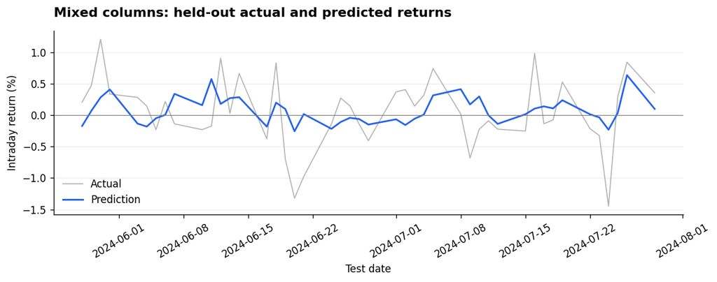

```python
plt.figure(figsize=(10, 4))
plt.plot(test["date"], test["intraday_ret"] * 100, color="grey", alpha=0.6, linewidth=1, label="Actual")
plt.plot(test["date"], test["prediction"] * 100, color=BLUE, linewidth=1.7, label="Prediction")
plt.axhline(0, color="grey", linewidth=0.7)
plt.title("Mixed columns: held-out actual and predicted returns")
plt.xlabel("Test date")
plt.ylabel("Intraday return (%)")
plt.legend()
plt.xticks(rotation=30)
plt.tight_layout()
plt.show()
```

**怎么看：** 图只展示测试段。新增 special 类别可以正常预测，因为 handle_unknown='ignore' 将这个类别在该 one-hot 特征块中编码为全0；它没有学到 special 的独有效应。下方小表特意打印了未知类别的预测，便于验证整个流程。

**换数据时注意：** 不要将类别直接编码成1、2、3后交给线性回归，除非类别真的有数值顺序。one-hot 的类别集合和填充值只能从训练期学习。本例每行是一个交易日；多资产面板应按日期整体切分。正式训练前还应处理训练期整列缺失的情况；这不是用全量数据补齐类别词典的理由。

## M05 · 涨跌分类：LogisticRegression 与混淆矩阵

**先看输入 DataFrame：** 以下是实际参与此例计算的数据预览。

```python
rng = np.random.RandomState(105)
n = 160
flow_z = rng.normal(size=n)
overnight_ret = rng.normal(0, 0.008, n)
vol_z = rng.normal(size=n)
latent_return = 0.9 * flow_z + 50 * overnight_ret - 0.4 * vol_z + rng.logistic(size=n)
df = pd.DataFrame({
    "date": pd.bdate_range("2024-01-02", periods=n),
    "flow_z": flow_z,
    "overnight_ret": overnight_ret,
    "vol_z": vol_z,
    "intraday_ret": 0.006 * np.tanh(latent_return),
})
df["target_up"] = (df["intraday_ret"] > 0).astype(int)
print("输入行数：", len(df))
display(df.head(8).round(5))
```

```
输入行数： 160
```

|  | date | flow_z | overnight_ret | vol_z | intraday_ret | target_up |
| --- | --- | --- | --- | --- | --- | --- |
| 0 | 2024-01-02 | -0.24533 | 0.01041 | 0.78032 | -0.00325 | 0 |
| 1 | 2024-01-03 | -0.61335 | 0.00354 | -1.12509 | 0.00394 | 1 |
| 2 | 2024-01-04 | -0.72677 | 0.01383 | 0.40707 | -0.00202 | 0 |
| 3 | 2024-01-05 | 0.05937 | 0.00094 | -0.45302 | 0.00038 | 1 |
| 4 | 2024-01-08 | 1.00558 | -0.00807 | -0.96766 | 0.00553 | 1 |
| 5 | 2024-01-09 | -0.12814 | 0.00108 | -0.84655 | 0.00565 | 1 |
| 6 | 2024-01-10 | -1.53399 | 0.01118 | -0.50560 | -0.00581 | 0 |
| 7 | 2024-01-11 | 0.47071 | 0.00838 | 0.32619 | 0.00477 | 1 |

**场景 / 要做什么：**

场景：预测当日收盘是否高于开盘。flow_z、overnight_ret、vol_z 是当天开盘前已知的特征；intraday_ret 是当日开盘至收盘收益，仅用来生成 target_up，不能放入 X。target_up=1 代表上涨，0代表不涨。按日期前70%训练、后30%测试；用固定0.5概率阈值，比较 LogisticRegression 与永远预测训练期多数类的 DummyClassifier。

**示例代码：** 明确选择特征，先切分再拟合，最后展示结果。

```python
from sklearn.pipeline import Pipeline
from sklearn.impute import SimpleImputer
from sklearn.preprocessing import StandardScaler
from sklearn.linear_model import LogisticRegression
from sklearn.dummy import DummyClassifier
from sklearn.metrics import accuracy_score, balanced_accuracy_score, confusion_matrix

df["date"] = pd.to_datetime(df["date"])
df = df.sort_values("date").reset_index(drop=True)
features = ["flow_z", "overnight_ret", "vol_z"]
split = int(len(df) * 0.7)
train, test = df.iloc[:split].copy(), df.iloc[split:].copy()
assert train["date"].max() < test["date"].min()
assert train["target_up"].nunique() == 2, "训练段需要同时含有上涨和不涨两类"
assert test["target_up"].nunique() == 2, "本例要求测试段含两类以比较 balanced accuracy"
model = Pipeline([("imputer", SimpleImputer(strategy="median")),
                  ("scaler", StandardScaler()),
                  ("logit", LogisticRegression(C=1.0, max_iter=1000, random_state=105))])
model.fit(train[features], train["target_up"])
test["prob_up"] = model.predict_proba(test[features])[:, 1]
test["prediction"] = (test["prob_up"] >= 0.5).astype(int)
baseline = DummyClassifier(strategy="most_frequent")
baseline.fit(train[features], train["target_up"])
test["baseline"] = baseline.predict(test[features])
display(pd.DataFrame({"train_count": train["target_up"].value_counts(),
                      "test_count": test["target_up"].value_counts()}).sort_index())
display(pd.DataFrame([
    {"model": c, "accuracy": accuracy_score(test["target_up"], test[c]),
     "balanced_accuracy": balanced_accuracy_score(test["target_up"], test[c])}
    for c in ["prediction", "baseline"]
]).set_index("model").round(4))
display(test[["date", "target_up", "prob_up", "prediction", "baseline"]].head(8).round(4))
cm = confusion_matrix(test["target_up"], test["prediction"], labels=[0, 1])
display(pd.DataFrame(cm, index=["Actual 0", "Actual 1"], columns=["Pred 0", "Pred 1"]))
```

|  | train_count | test_count |
| --- | --- | --- |
| 0 | 54 | 22 |
| 1 | 58 | 26 |

| model | accuracy | balanced_accuracy |
| --- | --- | --- |
| prediction | 0.7917 | 0.7867 |
| baseline | 0.5417 | 0.5000 |

|  | date | target_up | prob_up | prediction | baseline |
| --- | --- | --- | --- | --- | --- |
| 112 | 2024-06-06 | 1 | 0.7096 | 1 | 1 |
| 113 | 2024-06-07 | 1 | 0.6993 | 1 | 1 |
| 114 | 2024-06-10 | 1 | 0.7134 | 1 | 1 |
| 115 | 2024-06-11 | 1 | 0.7037 | 1 | 1 |
| 116 | 2024-06-12 | 1 | 0.7734 | 1 | 1 |
| 117 | 2024-06-13 | 1 | 0.3896 | 0 | 1 |
| 118 | 2024-06-14 | 1 | 0.8406 | 1 | 1 |
| 119 | 2024-06-17 | 0 | 0.7574 | 1 | 1 |

|  | Pred 0 | Pred 1 |
| --- | --- | --- |
| Actual 0 | 16 | 6 |
| Actual 1 | 4 | 22 |

**可视化：** 使用刚刚计算出的指标和预测。

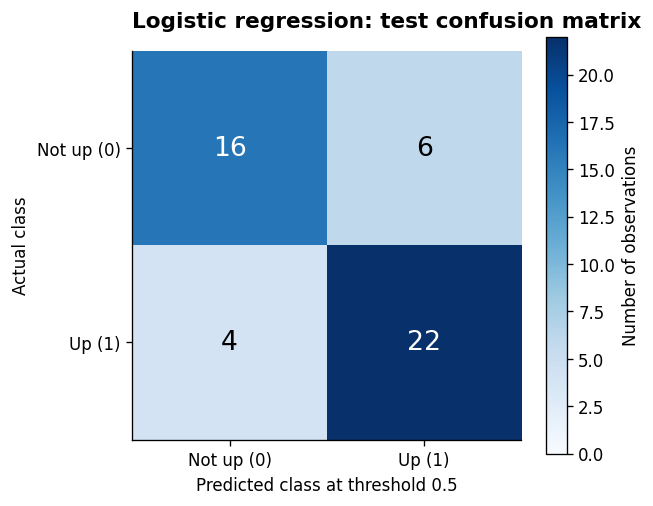

```python
plt.figure(figsize=(5.5, 4.5))
plt.imshow(cm, cmap="Blues", vmin=0)
plt.colorbar(label="Number of observations")
for row in range(2):
    for col in range(2):
        plt.text(col, row, str(cm[row, col]), ha="center", va="center", fontsize=16,
                 color="white" if cm[row, col] > cm.max() / 2 else "black")
plt.xticks([0, 1], ["Not up (0)", "Up (1)"])
plt.yticks([0, 1], ["Not up (0)", "Up (1)"])
plt.grid(False)
plt.title("Logistic regression: test confusion matrix")
plt.xlabel("Predicted class at threshold 0.5")
plt.ylabel("Actual class")
plt.tight_layout()
plt.show()
```

**怎么看：** 混淆矩阵纵轴是真实类别、横轴是预测类别；左上和右下是正确预测，右上是假阳性，左下是假阴性。accuracy 是整体正确率；balanced accuracy 是两类召回率的平均，能减少类别比例差异造成的误导。先与多数类基线比较，再判断分类器是否有增益。

**换数据时注意：** 阈值0.5预先固定，不根据这张测试混淆矩阵反复调整。概率质量、阈值选择和类别不平衡还需要单独验证；提高分类准确率不保证赚钱，因为涨跌幅和交易成本并不相同。本例的标准化分数是合成输入，实际构造时也必须避免用全样本均值或标准差。

## M06 · 涨跌分类：处理类别不平衡，在验证集选择概率阈值

**先看输入 DataFrame：** 以下是实际参与此例计算的数据预览。

```python
rng = np.random.default_rng(606)
n = 220
momentum = rng.normal(0, 1, n)
volatility = rng.uniform(0.008, 0.025, n)
flow = rng.normal(0, 1, n)
probability = 1 / (1 + np.exp(-(-1.5 + momentum + 0.7 * flow)))
label = rng.binomial(1, probability)
return_oc = np.where(label == 1, 1, -1) * rng.uniform(0.002, 0.015, n)
df = pd.DataFrame({"date": pd.bdate_range("2024-01-02", periods=n),
                   "momentum": momentum, "volatility": volatility,
                   "flow": flow, "return_oc": return_oc, "label": label})
print("总行数：", len(df))
display(df.head(8))
```

```
总行数： 220
```

|  | date | momentum | volatility | flow | return_oc | label |
| --- | --- | --- | --- | --- | --- | --- |
| 0 | 2024-01-02 | 0.259681 | 0.020161 | 1.865536 | -0.013260 | 0 |
| 1 | 2024-01-03 | 1.621342 | 0.010457 | -0.049447 | 0.012815 | 1 |
| 2 | 2024-01-04 | 0.356400 | 0.014012 | -1.447464 | -0.004707 | 0 |
| 3 | 2024-01-05 | 0.971490 | 0.013936 | 0.180143 | 0.008702 | 1 |
| 4 | 2024-01-08 | 0.736122 | 0.009428 | -1.053510 | -0.004991 | 0 |
| 5 | 2024-01-09 | 0.745304 | 0.014700 | -1.603663 | -0.007263 | 0 |
| 6 | 2024-01-10 | -1.417161 | 0.021494 | -0.702429 | -0.005945 | 0 |
| 7 | 2024-01-11 | 1.216670 | 0.024665 | 0.404515 | -0.003075 | 0 |

**场景 / 要做什么：**

每行是一日，momentum、volatility、flow 均在当日开盘前可用；label 是当日开盘到收盘收益 return_oc 是否大于 0。任务：预测上涨概率。按时间取前 60% 训练、中间 20% 验证、最后 20% 测试；模型先用 class_weight='balanced'，再只在验证集选择 F1 最大的阈值。测试集只做最终评价。

**示例代码：** 明确选择特征，先切分再拟合，最后展示结果。

```python
from sklearn.pipeline import make_pipeline
from sklearn.impute import SimpleImputer
from sklearn.preprocessing import StandardScaler
from sklearn.linear_model import LogisticRegression
from sklearn.metrics import f1_score, precision_score, recall_score
from sklearn.metrics import roc_auc_score, average_precision_score, confusion_matrix

df["date"] = pd.to_datetime(df["date"])
assert df["date"].notna().all() and df["date"].is_unique, "日期须非空且唯一"
df = df.sort_values("date").reset_index(drop=True)
features = ["momentum", "volatility", "flow"]
cut1, cut2 = int(len(df) * 0.6), int(len(df) * 0.8)
train, valid, test = df.iloc[:cut1], df.iloc[cut1:cut2], df.iloc[cut2:]
assert train["label"].nunique() == 2, "训练集必须含两个类别"
assert valid["label"].nunique() == 2, "验证集须含两个类别才能可靠选择阈值"

# 插补和标准化均只拟合训练集；类别权重也只基于训练集。
model = make_pipeline(SimpleImputer(strategy="median"), StandardScaler(),
                      LogisticRegression(class_weight="balanced", max_iter=1000,
                                         random_state=42))
model.fit(train[features], train["label"])
valid_probability = model.predict_proba(valid[features])[:, 1]
threshold_table = pd.DataFrame({"threshold": np.arange(0.2, 0.81, 0.1)})
threshold_table["valid_f1"] = [
    f1_score(valid["label"], valid_probability >= t, zero_division=0)
    for t in threshold_table["threshold"]]
threshold = threshold_table.loc[threshold_table["valid_f1"].idxmax(), "threshold"]
display(threshold_table.round(3))

# 阈值已经锁定，不再根据测试结果重新选阈值。
test_probability = model.predict_proba(test[features])[:, 1]
test_prediction = (test_probability >= threshold).astype(int)
y_test = test["label"]
has_two_classes = y_test.nunique() == 2
metrics = pd.DataFrame([{
    "threshold_from_valid": threshold, "test_positive_rate": y_test.mean(),
    "precision": precision_score(y_test, test_prediction, zero_division=0),
    "recall": recall_score(y_test, test_prediction, zero_division=0),
    "f1": f1_score(y_test, test_prediction, zero_division=0),
    "roc_auc": roc_auc_score(y_test, test_probability) if has_two_classes else np.nan,
    "average_precision": average_precision_score(y_test, test_probability) if has_two_classes else np.nan}])
display(metrics.round(3))
display(pd.DataFrame(confusion_matrix(y_test, test_prediction, labels=[0, 1]),
                     index=["actual_0", "actual_1"], columns=["predicted_0", "predicted_1"]))
if not has_two_classes:
    print("测试集只有一个类别：不报告 ROC-AUC / AP，也不画 PR 曲线。")
```

|  | threshold | valid_f1 |
| --- | --- | --- |
| 0 | 0.2 | 0.565 |
| 1 | 0.3 | 0.571 |
| 2 | 0.4 | 0.595 |
| 3 | 0.5 | 0.621 |
| 4 | 0.6 | 0.417 |
| 5 | 0.7 | 0.364 |
| 6 | 0.8 | 0.353 |

|  | threshold_from_valid | test_positive_rate | precision | recall | f1 | roc_auc | average_precision |
| --- | --- | --- | --- | --- | --- | --- | --- |
| 0 | 0.5 | 0.136 | 0.273 | 0.5 | 0.353 | 0.75 | 0.461 |

|  | predicted_0 | predicted_1 |
| --- | --- | --- |
| actual_0 | 30 | 8 |
| actual_1 | 3 | 3 |

**可视化：** 使用刚刚计算出的指标和预测。

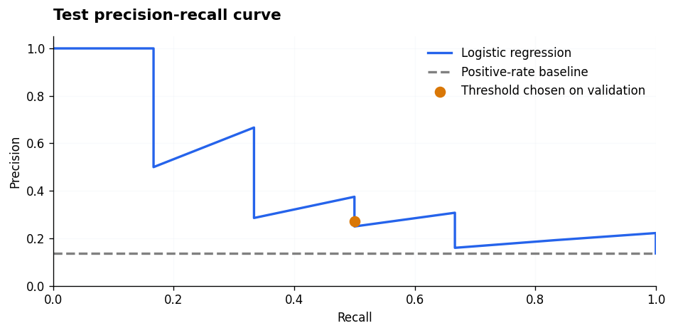

```python
from sklearn.metrics import precision_recall_curve

if has_two_classes:
    precision, recall, _ = precision_recall_curve(y_test, test_probability)
    plt.figure(figsize=(8, 4))
    plt.plot(recall, precision, color=BLUE, linewidth=2, label="Logistic regression")
    plt.axhline(y_test.mean(), color="grey", linestyle="--", label="Positive-rate baseline")
    plt.scatter(metrics.loc[0, "recall"], metrics.loc[0, "precision"],
                color=ORANGE, s=70, zorder=3, label="Threshold chosen on validation")
    plt.title("Test precision-recall curve")
    plt.xlabel("Recall")
    plt.ylabel("Precision")
    plt.xlim(0, 1)
    plt.ylim(0, 1.05)
    plt.legend()
    plt.grid(alpha=0.2)
    plt.tight_layout()
    plt.show()
```

**怎么看：** 先读混淆表：行是真实类别，列是预测类别。PR 曲线适合关注少数正类的场景，橙点是验证集选定阈值在测试集上的结果；虚线是测试集正类比例。AP 是 average precision，不应把它与任意方式计算的曲线梯形面积混为一谈。

**换数据时注意：** 本例用 F1 选阈值是分类教学，不代表交易收益最优。class_weight 会改变拟合目标，predict_proba 未必是校准后的真实概率；如需校准，另外保留按时间分割的校准数据。不要为让曲线更好看而在测试集重选阈值，也不要仅凭 accuracy 评价不平衡分类。

## M07 · 决策树回归：用验证误差选择深度，观察过拟合

**先看输入 DataFrame：** 以下是实际参与此例计算的数据预览。

```python
rng = np.random.default_rng(707)
n = 210
momentum = rng.normal(0, 1, n)
volatility = rng.uniform(0.008, 0.025, n)
flow = rng.normal(0, 1, n)
return_oc = (0.006 * np.tanh(1.5 * momentum) + 0.004 * (flow > 0)
             - 0.15 * volatility + rng.normal(0, 0.005, n))
df = pd.DataFrame({"date": pd.bdate_range("2024-01-02", periods=n),
                   "momentum": momentum, "volatility": volatility,
                   "flow": flow, "return_oc": return_oc})
print("总行数：", len(df))
display(df.head(8))
```

```
总行数： 210
```

|  | date | momentum | volatility | flow | return_oc |
| --- | --- | --- | --- | --- | --- |
| 0 | 2024-01-02 | -0.140768 | 0.009262 | -0.137980 | -0.005903 |
| 1 | 2024-01-03 | -2.658545 | 0.019005 | -1.039079 | -0.009044 |
| 2 | 2024-01-04 | 1.835415 | 0.022449 | -0.997607 | 0.005611 |
| 3 | 2024-01-05 | -0.695707 | 0.021865 | -0.612634 | -0.003775 |
| 4 | 2024-01-08 | -0.704557 | 0.011917 | 0.871232 | -0.003939 |
| 5 | 2024-01-09 | 0.079447 | 0.023197 | -0.191084 | 0.002488 |
| 6 | 2024-01-10 | 0.160819 | 0.018567 | 1.642566 | -0.003054 |
| 7 | 2024-01-11 | 0.009241 | 0.021927 | 0.092230 | 0.004714 |

**场景 / 要做什么：**

用三个盘前可用特征预测当日开盘到收盘收益 return_oc。任务：比较不同 max_depth 的训练和验证 RMSE。按时间使用前 60% 训练、中间 20% 验证、最后 20% 测试；只用验证集选深度，随后在训练集与验证集合并数据上重训，最后只评价一次测试集。

**示例代码：** 明确选择特征，先切分再拟合，最后展示结果。

```python
from sklearn.tree import DecisionTreeRegressor
from sklearn.metrics import mean_squared_error

df["date"] = pd.to_datetime(df["date"])
assert df["date"].notna().all() and df["date"].is_unique, "日期须非空且唯一"
df = df.sort_values("date").reset_index(drop=True)
features = ["momentum", "volatility", "flow"]
cut1, cut2 = int(len(df) * 0.6), int(len(df) * 0.8)
train, valid, test = df.iloc[:cut1], df.iloc[cut1:cut2], df.iloc[cut2:]
depths = [1, 2, 3, 4, 6, None]
scores = []
for depth in depths:
    model = DecisionTreeRegressor(max_depth=depth, min_samples_leaf=2, random_state=42)
    model.fit(train[features], train["return_oc"])
    scores.append({"depth": str(depth),
                   "train_rmse": np.sqrt(mean_squared_error(train["return_oc"], model.predict(train[features]))),
                   "valid_rmse": np.sqrt(mean_squared_error(valid["return_oc"], model.predict(valid[features])))})
depth_table = pd.DataFrame(scores)
display(depth_table.round(5))

best_depth = depths[depth_table["valid_rmse"].idxmin()]
train_valid = df.iloc[:cut2]
final_model = DecisionTreeRegressor(max_depth=best_depth, min_samples_leaf=2, random_state=42)
final_model.fit(train_valid[features], train_valid["return_oc"])
prediction = final_model.predict(test[features])
baseline = np.repeat(train_valid["return_oc"].mean(), len(test))
display(pd.DataFrame([{"selected_depth": str(best_depth),
                       "test_rmse": np.sqrt(mean_squared_error(test["return_oc"], prediction)),
                       "mean_baseline_rmse": np.sqrt(mean_squared_error(test["return_oc"], baseline))}]).round(5))
result = test[["date", "return_oc"]].assign(prediction=prediction)
display(result.head(8))
```

|  | depth | train_rmse | valid_rmse |
| --- | --- | --- | --- |
| 0 | 1 | 0.00516 | 0.00582 |
| 1 | 2 | 0.00473 | 0.00562 |
| 2 | 3 | 0.00419 | 0.00634 |
| 3 | 4 | 0.00367 | 0.00641 |
| 4 | 6 | 0.00241 | 0.00697 |
| 5 | None | 0.00165 | 0.00720 |

|  | selected_depth | test_rmse | mean_baseline_rmse |
| --- | --- | --- | --- |
| 0 | 2 | 0.00635 | 0.00813 |

|  | date | return_oc | prediction |
| --- | --- | --- | --- |
| 168 | 2024-08-23 | 0.003964 | -0.001534 |
| 169 | 2024-08-26 | -0.001296 | -0.007251 |
| 170 | 2024-08-27 | -0.005854 | 0.002220 |
| 171 | 2024-08-28 | -0.010330 | -0.007251 |
| 172 | 2024-08-29 | -0.005990 | 0.002220 |
| 173 | 2024-08-30 | 0.009110 | 0.004886 |
| 174 | 2024-09-02 | 0.006676 | 0.004886 |
| 175 | 2024-09-03 | -0.000995 | -0.001534 |

**可视化：** 使用刚刚计算出的指标和预测。

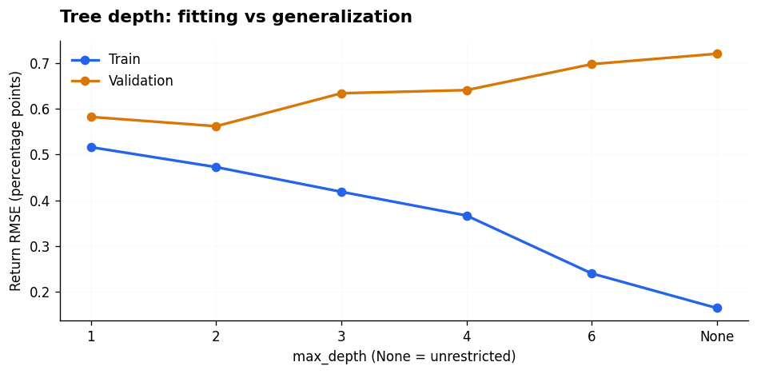

```python
plt.figure(figsize=(8, 4))
plt.plot(depth_table["depth"], depth_table["train_rmse"] * 100,
         color=BLUE, marker="o", linewidth=2, label="Train")
plt.plot(depth_table["depth"], depth_table["valid_rmse"] * 100,
         color=ORANGE, marker="o", linewidth=2, label="Validation")
plt.title("Tree depth: fitting vs generalization")
plt.xlabel("max_depth (None = unrestricted)")
plt.ylabel("Return RMSE (percentage points)")
plt.legend()
plt.grid(alpha=0.2)
plt.tight_layout()
plt.show()
```

**怎么看：** 训练 RMSE 随树变深通常下降；如果验证 RMSE 开始上升，说明模型可能在拟合噪声。图中展示的是候选模型在固定训练/验证集上的表现，测试集完全不参与这张选参图。最终表格报告在训练加验证数据上重训后的测试误差。

**换数据时注意：** 只有一次时间切分时，选出的深度可能对该段行情敏感；样本多时可改为带必要 gap 的 TimeSeriesSplit。不要查看测试误差后继续搜索深度。真实特征有缺失时，把 SimpleImputer 放进 Pipeline，并在每次候选训练时只拟合训练数据。

## M08 · 随机森林：学习非线性，和训练均值基准比较

**先看输入 DataFrame：** 以下是实际参与此例计算的数据预览。

```python
rng = np.random.default_rng(808)
n = 220
momentum = rng.normal(0, 1, n)
volatility = rng.uniform(0.008, 0.025, n)
flow = rng.normal(0, 1, n)
return_oc = (0.008 * np.tanh(momentum) + 0.004 * momentum * (flow > 0)
             - 0.12 * volatility + rng.normal(0, 0.003, n))
df = pd.DataFrame({"date": pd.bdate_range("2024-01-02", periods=n),
                   "momentum": momentum, "volatility": volatility,
                   "flow": flow, "return_oc": return_oc})
print("总行数：", len(df))
display(df.head(8))
```

```
总行数： 220
```

|  | date | momentum | volatility | flow | return_oc |
| --- | --- | --- | --- | --- | --- |
| 0 | 2024-01-02 | -0.993138 | 0.020814 | -1.441869 | -0.005278 |
| 1 | 2024-01-03 | 0.758491 | 0.020255 | 0.625989 | 0.005028 |
| 2 | 2024-01-04 | 0.603458 | 0.014433 | -0.927903 | 0.002808 |
| 3 | 2024-01-05 | -0.914226 | 0.018980 | 0.594565 | -0.006786 |
| 4 | 2024-01-08 | 0.025383 | 0.020340 | 2.195853 | -0.011538 |
| 5 | 2024-01-09 | 0.157305 | 0.011908 | -0.040166 | -0.002037 |
| 6 | 2024-01-10 | -2.536503 | 0.008733 | 0.865701 | -0.011718 |
| 7 | 2024-01-11 | 0.271312 | 0.012349 | 0.479715 | 0.000466 |

**场景 / 要做什么：**

三个特征在开盘前可用，目标是同日开盘到收盘收益。任务：按时间取前 80% 训练随机森林，最后 20% 作为测试；用预先固定的深度和叶节点样本数控制复杂度，并与只预测训练集均值的 DummyRegressor 比较。树模型不要求特征标准化。

**示例代码：** 明确选择特征，先切分再拟合，最后展示结果。

```python
from sklearn.pipeline import make_pipeline
from sklearn.impute import SimpleImputer
from sklearn.ensemble import RandomForestRegressor
from sklearn.dummy import DummyRegressor
from sklearn.metrics import mean_squared_error, mean_absolute_error, r2_score

df["date"] = pd.to_datetime(df["date"])
assert df["date"].notna().all() and df["date"].is_unique, "日期须非空且唯一"
df = df.sort_values("date").reset_index(drop=True)
features = ["momentum", "volatility", "flow"]
cut = int(len(df) * 0.8)
train, test = df.iloc[:cut], df.iloc[cut:]
# 这些参数事先指定；若要调参，须在 train 内再按时间保留验证集。
model = make_pipeline(SimpleImputer(strategy="median"),
                      RandomForestRegressor(n_estimators=150, max_depth=6,
                                            min_samples_leaf=5, max_features=1.0,
                                            random_state=42, n_jobs=1))
model.fit(train[features], train["return_oc"])
prediction = model.predict(test[features])
baseline = DummyRegressor(strategy="mean")
baseline.fit(train[features], train["return_oc"])
baseline_prediction = baseline.predict(test[features])
scores = []
for name, pred in [("Random forest", prediction), ("Training mean", baseline_prediction)]:
    scores.append({"model": name,
                   "test_rmse": np.sqrt(mean_squared_error(test["return_oc"], pred)),
                   "test_mae": mean_absolute_error(test["return_oc"], pred),
                   "test_r2": r2_score(test["return_oc"], pred) if test["return_oc"].nunique() > 1 else np.nan})
display(pd.DataFrame(scores).round(5))
result = test[["date", "return_oc"]].assign(prediction=prediction)
display(result.head(8))
```

|  | model | test_rmse | test_mae | test_r2 |
| --- | --- | --- | --- | --- |
| 0 | Random forest | 0.00341 | 0.00278 | 0.81163 |
| 1 | Training mean | 0.00797 | 0.00636 | -0.02571 |

|  | date | return_oc | prediction |
| --- | --- | --- | --- |
| 176 | 2024-09-04 | -0.004350 | -0.005301 |
| 177 | 2024-09-05 | -0.009948 | -0.007510 |
| 178 | 2024-09-06 | 0.004397 | 0.005576 |
| 179 | 2024-09-09 | 0.009319 | 0.008302 |
| 180 | 2024-09-10 | -0.005362 | -0.007173 |
| 181 | 2024-09-11 | -0.001691 | -0.000435 |
| 182 | 2024-09-12 | -0.005535 | -0.005351 |
| 183 | 2024-09-13 | -0.003645 | -0.000697 |

**可视化：** 使用刚刚计算出的指标和预测。

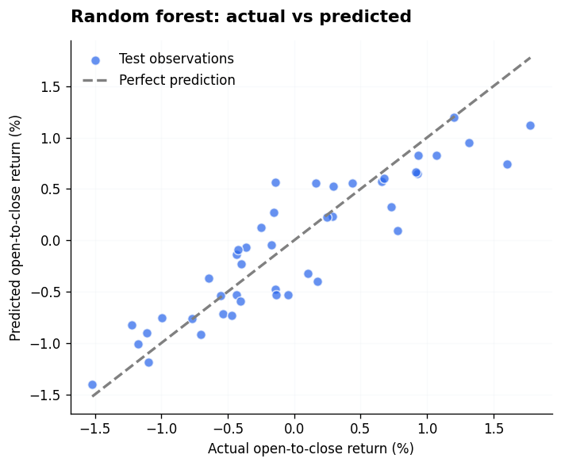

```python
actual_pct = result["return_oc"] * 100
predicted_pct = result["prediction"] * 100
lo = min(actual_pct.min(), predicted_pct.min())
hi = max(actual_pct.max(), predicted_pct.max())
plt.figure(figsize=(6, 5))
plt.scatter(actual_pct, predicted_pct, color=BLUE, alpha=0.7,
            edgecolors="white", s=50, label="Test observations")
plt.plot([lo, hi], [lo, hi], color="grey", linestyle="--", label="Perfect prediction")
plt.title("Random forest: actual vs predicted")
plt.xlabel("Actual open-to-close return (%)")
plt.ylabel("Predicted open-to-close return (%)")
plt.legend()
plt.grid(alpha=0.2)
plt.tight_layout()
plt.show()
```

**怎么看：** 散点越接近对角线，单次预测误差越小；若预测集中在零附近但真实收益分散，模型可能对极端值预测不足。先比较测试 RMSE 与训练均值基准，不要只看散点是否有倾斜趋势。R² 可以为负，表示相对于测试样本自身均值的平方误差基准表现更差；测试目标为常数时，本例将无法正常定义的 R² 记为 NaN。

**换数据时注意：** 时间序列不能用随机森林 OOB 分数替代按时间验证；普通 bootstrap 训练没有保证 OOB 行只由其过去的数据预测。不要将 feature_importances_ 当作因果关系。这里的可预测模式是人为生成的，真实收益的样本外信号通常弱得多。

## M09 · HistGradientBoosting：原生处理缺失值的提升树

**先看输入 DataFrame：** 以下是实际参与此例计算的数据预览。

```python
rng = np.random.default_rng(909)
n = 220
momentum = rng.normal(0, 1, n)
volatility = rng.uniform(0.008, 0.025, n)
flow = rng.normal(0, 1, n)
return_oc = (0.006 * np.tanh(momentum) + 0.004 * (flow > 0.3)
             - 0.2 * volatility + rng.normal(0, 0.004, n))
df = pd.DataFrame({"date": pd.bdate_range("2024-01-02", periods=n),
                   "momentum": momentum, "volatility": volatility,
                   "flow": flow, "return_oc": return_oc})
# 模拟盘前部分特征缺报：目标仍完整，模型直接接收数值 NaN。
df.loc[rng.choice(n, 22, replace=False), "flow"] = np.nan
df.loc[rng.choice(n, 11, replace=False), "momentum"] = np.nan
print("总行数：", len(df))
display(df.head(8))
```

```
总行数： 220
```

|  | date | momentum | volatility | flow | return_oc |
| --- | --- | --- | --- | --- | --- |
| 0 | 2024-01-02 | -0.792537 | 0.021140 | 0.653595 | 0.000669 |
| 1 | 2024-01-03 | 0.606491 | 0.020755 | -0.514387 | 0.002837 |
| 2 | 2024-01-04 | -0.634962 | 0.018502 | -0.299819 | -0.003742 |
| 3 | 2024-01-05 | -1.151442 | 0.012159 | 1.209117 | -0.006734 |
| 4 | 2024-01-08 | 0.431703 | 0.022446 | -0.087063 | -0.001334 |
| 5 | 2024-01-09 | -0.416643 | 0.016716 | -0.133484 | -0.006420 |
| 6 | 2024-01-10 | -0.952510 | 0.019047 | 1.219870 | 0.001615 |
| 7 | 2024-01-11 | NaN | 0.019537 | 0.373793 | -0.001677 |

**场景 / 要做什么：**

用盘前数值特征预测同日开盘到收盘收益，输入特征存在 NaN。任务：使用 scikit-learn 自带的 HistGradientBoostingRegressor，按时间取前 80% 训练、后 20% 测试。明确关闭默认 early stopping，以避免训练过程再随机划分内部验证集；参数在看测试集前固定。

**示例代码：** 明确选择特征，先切分再拟合，最后展示结果。

```python
from sklearn.ensemble import HistGradientBoostingRegressor
from sklearn.metrics import mean_squared_error, mean_absolute_error

df["date"] = pd.to_datetime(df["date"])
assert df["date"].notna().all() and df["date"].is_unique, "日期须非空且唯一"
df = df.sort_values("date").reset_index(drop=True)
features = ["momentum", "volatility", "flow"]
cut = int(len(df) * 0.8)
train, test = df.iloc[:cut], df.iloc[cut:]
display(df[features].isna().sum().rename("missing_count").to_frame())
# 数值特征的 NaN 由模型处理；目标 y 不能缺失。
assert df["return_oc"].notna().all(), "先去掉没有可观测标签的行"
model = HistGradientBoostingRegressor(max_iter=140, learning_rate=0.06,
                                     max_leaf_nodes=7, min_samples_leaf=12,
                                     l2_regularization=0.1, early_stopping=False,
                                     random_state=42)
model.fit(train[features], train["return_oc"])
prediction = model.predict(test[features])
result = test[["date", "return_oc"]].assign(prediction=prediction)
result["residual"] = result["return_oc"] - result["prediction"]
display(result.head(8))
display(pd.DataFrame([{
    "test_rmse": np.sqrt(mean_squared_error(test["return_oc"], prediction)),
    "test_mae": mean_absolute_error(test["return_oc"], prediction),
    "mean_baseline_rmse": np.sqrt(mean_squared_error(test["return_oc"],
                                                      np.repeat(train["return_oc"].mean(), len(test))))}]).round(5))
```

|  | missing_count |
| --- | --- |
| momentum | 11 |
| volatility | 0 |
| flow | 22 |

|  | date | return_oc | prediction | residual |
| --- | --- | --- | --- | --- |
| 176 | 2024-09-04 | 0.006556 | 0.000511 | 0.006045 |
| 177 | 2024-09-05 | -0.001599 | -0.003630 | 0.002031 |
| 178 | 2024-09-06 | -0.006262 | -0.005259 | -0.001002 |
| 179 | 2024-09-09 | 0.007434 | 0.003111 | 0.004324 |
| 180 | 2024-09-10 | -0.003289 | -0.006202 | 0.002913 |
| 181 | 2024-09-11 | -0.000964 | -0.000163 | -0.000801 |
| 182 | 2024-09-12 | -0.003134 | 0.002312 | -0.005446 |
| 183 | 2024-09-13 | 0.000213 | -0.001328 | 0.001540 |

|  | test_rmse | test_mae | mean_baseline_rmse |
| --- | --- | --- | --- |
| 0 | 0.00434 | 0.00358 | 0.00622 |

**可视化：** 使用刚刚计算出的指标和预测。

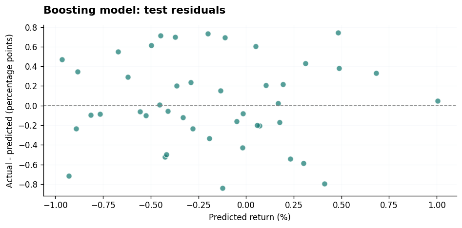

```python
plt.figure(figsize=(8, 4))
plt.scatter(result["prediction"] * 100, result["residual"] * 100,
            color=TEAL, alpha=0.7, edgecolors="white", s=50)
plt.axhline(0, color="grey", linestyle="--", linewidth=1)
plt.title("Boosting model: test residuals")
plt.xlabel("Predicted return (%)")
plt.ylabel("Actual - predicted (percentage points)")
plt.grid(alpha=0.2)
plt.tight_layout()
plt.show()
```

**怎么看：** 残差定义为实际值减预测值，位于零线上方表示低估。若残差随预测值出现弯曲趋势，可能遗漏了结构；若散布逐渐变宽，可能存在异方差。此图是测试集诊断，应在后续新一轮研究中处理发现的问题，不能反复用同一测试集调参。

**换数据时注意：** 原生接受 NaN 不代表任何缺失机制都无害：先分辨缺报、停牌与数据延迟，不能把尚未发布的特征填进来。模型不会原生接受正负无穷值，也不能拟合缺失标签。固定迭代数是最短模板；需要调参时使用训练区间内的时间验证或 TimeSeriesSplit。

## M10 · XGBoost（可选依赖）：按时间验证与 early stopping

**先看输入 DataFrame：** 以下是实际参与此例计算的数据预览。

```python
rng = np.random.default_rng(1010)
n = 220
momentum = rng.normal(0, 1, n)
volatility = rng.uniform(0.008, 0.025, n)
flow = rng.normal(0, 1, n)
return_oc = (0.007 * np.tanh(momentum) + 0.004 * (flow > 0)
             - 0.1 * volatility + rng.normal(0, 0.004, n))
df = pd.DataFrame({"date": pd.bdate_range("2024-01-02", periods=n),
                   "momentum": momentum, "volatility": volatility,
                   "flow": flow, "return_oc": return_oc})
print("总行数：", len(df))
display(df.head(8))
```

```
总行数： 220
```

|  | date | momentum | volatility | flow | return_oc |
| --- | --- | --- | --- | --- | --- |
| 0 | 2024-01-02 | -1.698700 | 0.016466 | 0.758370 | -0.005118 |
| 1 | 2024-01-03 | 0.537997 | 0.012374 | 0.272931 | 0.000679 |
| 2 | 2024-01-04 | -0.225614 | 0.024468 | -0.232097 | -0.001600 |
| 3 | 2024-01-05 | -1.090209 | 0.024964 | 0.031489 | -0.008123 |
| 4 | 2024-01-08 | 0.553913 | 0.011063 | 1.212342 | 0.005380 |
| 5 | 2024-01-09 | -1.501154 | 0.018733 | 1.136139 | -0.001905 |
| 6 | 2024-01-10 | 0.445459 | 0.009339 | 0.934520 | 0.009343 |
| 7 | 2024-01-11 | 1.344817 | 0.012742 | -1.631779 | 0.001142 |

**场景 / 要做什么：**

特征在盘前可用，目标 return_oc 是同日开盘到收盘收益。任务：按时间取前 60% 训练、中间 20% 验证、最后 20% 测试。用验证 RMSE 决定停止轮数，测试集不进入 eval_set。本例需要可选包 xgboost；未安装时明确跳过，不改用其他模型冒充运行结果。

**示例代码：** 明确选择特征，先切分再拟合，最后展示结果。

```python
from sklearn.metrics import mean_squared_error, mean_absolute_error

try:
    from xgboost import XGBRegressor
    xgb_available = True
except (ImportError, OSError, ValueError) as exc:
    # XGBoostError 继承 ValueError；缺少 OpenMP 动态库时也要明确跳过。
    xgb_available = False
    print("跳过 M10：XGBoost 未安装或动态库加载失败。请按 Notebook 开头的安装说明配置后重跑。")
    print(type(exc).__name__ + ": " + str(exc).strip().splitlines()[0])

if xgb_available:
    df["date"] = pd.to_datetime(df["date"])
    assert df["date"].notna().all() and df["date"].is_unique, "日期须非空且唯一"
    df = df.sort_values("date").reset_index(drop=True)
    features = ["momentum", "volatility", "flow"]
    cut1, cut2 = int(len(df) * 0.6), int(len(df) * 0.8)
    train, valid, test = df.iloc[:cut1], df.iloc[cut1:cut2], df.iloc[cut2:]
    # early_stopping_rounds 放在构造器中，兼容 XGBoost 2.0.3 和较新版本。
    model = XGBRegressor(n_estimators=300, learning_rate=0.05, max_depth=2,
                         min_child_weight=5, reg_lambda=5, objective="reg:squarederror",
                         eval_metric="rmse", tree_method="hist", early_stopping_rounds=15,
                         random_state=42, n_jobs=1)
    model.fit(train[features], train["return_oc"],
              eval_set=[(train[features], train["return_oc"]),
                        (valid[features], valid["return_oc"])], verbose=False)
    # 最后一份 eval_set（验证集）用于 early stopping；predict 自动使用最佳轮数。
    history = model.evals_result()
    prediction = model.predict(test[features])
    result = test[["date", "return_oc"]].assign(prediction=prediction)
    display(result.head(8))
    display(pd.DataFrame([{
        "best_round": model.best_iteration + 1,
        "test_rmse": np.sqrt(mean_squared_error(test["return_oc"], prediction)),
        "test_mae": mean_absolute_error(test["return_oc"], prediction),
        "mean_baseline_rmse": np.sqrt(mean_squared_error(test["return_oc"],
                                                          np.repeat(train["return_oc"].mean(), len(test))))}]).round(5))
```

|  | date | return_oc | prediction |
| --- | --- | --- | --- |
| 176 | 2024-09-04 | -0.013535 | -0.008566 |
| 177 | 2024-09-05 | 0.002882 | 0.002271 |
| 178 | 2024-09-06 | 0.006159 | 0.004557 |
| 179 | 2024-09-09 | 0.008574 | 0.005152 |
| 180 | 2024-09-10 | -0.008162 | -0.001081 |
| 181 | 2024-09-11 | -0.001057 | -0.003647 |
| 182 | 2024-09-12 | -0.009728 | -0.005978 |
| 183 | 2024-09-13 | 0.008071 | 0.006618 |

|  | best_round | test_rmse | test_mae | mean_baseline_rmse |
| --- | --- | --- | --- | --- |
| 0 | 179 | 0.00405 | 0.00334 | 0.00647 |

**可视化：** 使用刚刚计算出的指标和预测。

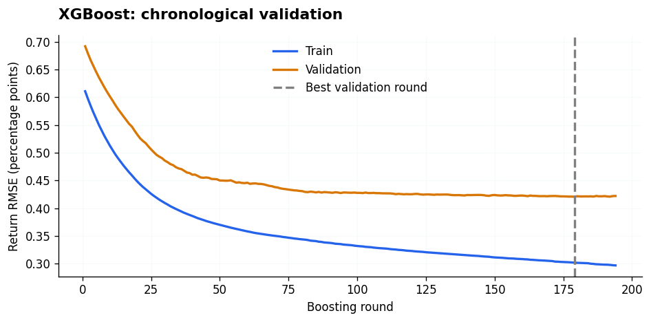

```python
if xgb_available:
    train_rmse = np.array(history["validation_0"]["rmse"])
    valid_rmse = np.array(history["validation_1"]["rmse"])
    rounds = np.arange(1, len(train_rmse) + 1)
    plt.figure(figsize=(8, 4))
    plt.plot(rounds, train_rmse * 100, color=BLUE, linewidth=2, label="Train")
    plt.plot(rounds, valid_rmse * 100, color=ORANGE, linewidth=2, label="Validation")
    plt.axvline(model.best_iteration + 1, color="grey", linestyle="--", label="Best validation round")
    plt.title("XGBoost: chronological validation")
    plt.xlabel("Boosting round")
    plt.ylabel("Return RMSE (percentage points)")
    plt.legend()
    plt.grid(alpha=0.2)
    plt.tight_layout()
    plt.show()
else:
    print("M10 图表已跳过：需要先成功加载并训练 XGBoost。")
```

**怎么看：** 蓝线是训练误差，橙线是后续时间段的验证误差；虚线标出验证误差最小的迭代轮数。early stopping 会继续观察若干轮，所以曲线可能延伸到虚线之后。测试集仅出现在结果表，不参与轮数选择或学习曲线。

**换数据时注意：** 当 eval_set 有多个数据集时，最后一个用于 early stopping；不要把测试集放在最后。学习率、树深度等若继续搜索，也只能用训练区间和验证集。该模板直接保留 early stopping 得到的模型；若改为合并训练与验证集重训，须先固定最佳轮数并移除 early stopping。

## M11 · TimeSeriesSplit + GridSearchCV：带间隔的时间调参

**先看输入 DataFrame：** 以下是实际参与此例计算的数据预览。

```python
rng = np.random.RandomState(111)
df = pd.DataFrame({
    'date': pd.bdate_range('2023-01-02', periods=190),
    'close': 100 * np.exp(np.cumsum(rng.normal(0.0002, 0.01, 190))),
})
print('输入共', len(df), '行；先看前8行')
display(df.head(8))
```

```
输入共 190 行；先看前8行
```

|  | date | close |
| --- | --- | --- |
| 0 | 2023-01-02 | 98.892342 |
| 1 | 2023-01-03 | 99.292992 |
| 2 | 2023-01-04 | 100.810300 |
| 3 | 2023-01-05 | 100.472766 |
| 4 | 2023-01-06 | 99.704556 |
| 5 | 2023-01-09 | 99.267377 |
| 6 | 2023-01-10 | 99.228503 |
| 7 | 2023-01-11 | 98.897461 |

**场景 / 要做什么：**

**场景：** 用截至当天收盘的历史收益与波动，预测未来 3 个观测期的收益。`date` 是会话日期，`close` 为一致口径的正价格。

**要做什么：** 先保留时间最晚的 20% 作为最终测试集；开发集内部使用 `TimeSeriesSplit(gap=3)` 搜索 Ridge 的 alpha。用 Pipeline 确保每个 fold 单独拟合填充器和标准化。每行同时记录 16:05 的预测时间及标签在未来 16:00 的实现时间；训练标签必须先于预测可用。

**示例代码：** 明确选择特征，先切分再拟合，最后展示结果。

```python
from sklearn.pipeline import make_pipeline
from sklearn.impute import SimpleImputer
from sklearn.preprocessing import StandardScaler
from sklearn.linear_model import Ridge
from sklearn.model_selection import TimeSeriesSplit, GridSearchCV
from sklearn.metrics import mean_squared_error

data = df.copy()
data['date'] = pd.to_datetime(data['date'])
data = data.sort_values('date').reset_index(drop=True)
assert data['date'].notna().all() and data['date'].is_unique
assert np.isfinite(data['close']).all() and data['close'].gt(0).all()
horizon = 3
ret = data['close'].pct_change(fill_method=None)
data['momentum'] = data['close'].pct_change(3, fill_method=None)
data['volatility'] = ret.rolling(5).std()
data['target'] = data['close'].shift(-horizon) / data['close'] - 1
data['prediction_time'] = data['date'] + pd.Timedelta(hours=16, minutes=5)
data['label_end'] = data['date'].shift(-horizon) + pd.Timedelta(hours=16)
features = ['momentum', 'volatility']
samples = data.dropna(subset=features + ['target', 'label_end']).reset_index(drop=True)
test_start = samples.loc[int(len(samples) * 0.8), 'prediction_time']
dev = samples.loc[(samples['prediction_time'] < test_start) & (samples['label_end'] < test_start)]
test = samples.loc[samples['prediction_time'] >= test_start]
cv = TimeSeriesSplit(n_splits=3, test_size=20, gap=horizon)
for train_i, valid_i in cv.split(dev):
    assert dev.iloc[train_i]['label_end'].max() < dev.iloc[valid_i]['prediction_time'].min()
pipeline = make_pipeline(SimpleImputer(strategy='median'), StandardScaler(), Ridge())
search = GridSearchCV(pipeline, {'ridge__alpha': [0.1, 1, 10, 100]}, cv=cv,
                      scoring='neg_mean_squared_error', n_jobs=1, refit=True)
search.fit(dev[features], dev['target'])
cv_table = pd.DataFrame({
    'alpha': [p['ridge__alpha'] for p in search.cv_results_['params']],
    'CV_RMSE': np.sqrt(-search.cv_results_['mean_test_score']),
})
test_prediction = search.predict(test[features])  # 参数已锁定，这时才评估最终test。
display(cv_table.round(6))
display(pd.DataFrame({'best_alpha': [search.best_params_['ridge__alpha']],
                      'test_RMSE': [np.sqrt(mean_squared_error(test['target'], test_prediction))]}))
```

|  | alpha | CV_RMSE |
| --- | --- | --- |
| 0 | 0.1 | 0.016279 |
| 1 | 1.0 | 0.016277 |
| 2 | 10.0 | 0.016256 |
| 3 | 100.0 | 0.016238 |

|  | best_alpha | test_RMSE |
| --- | --- | --- |
| 0 | 100 | 0.021538 |

**可视化：** 使用刚刚计算出的指标和预测。

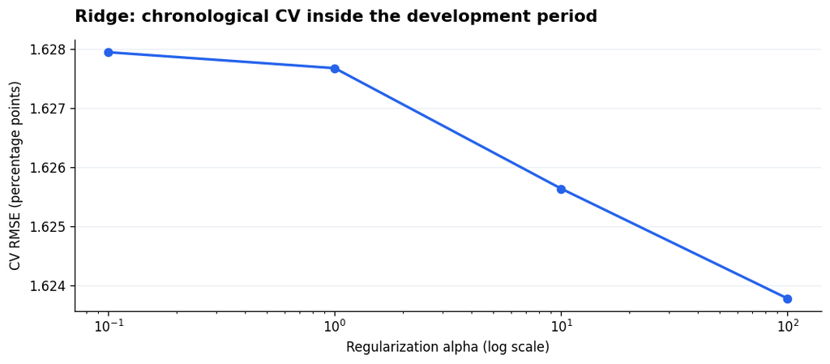

```python
plt.figure(figsize=(9, 4))
plt.plot(cv_table['alpha'], cv_table['CV_RMSE'] * 100, color=BLUE, marker='o')
plt.xscale('log')
plt.title('Ridge: chronological CV inside the development period')
plt.xlabel('Regularization alpha (log scale)')
plt.ylabel('CV RMSE (percentage points)')
plt.tight_layout()
plt.show()
```

**怎么看：** 横轴是惩罚强度，纵轴是开发集内部各验证 fold 的平均 MSE 再开方；越低越好。最终测试误差单独在表中报告，不参与选 alpha。

**换数据时注意：** gap 是样本行数，不自动代表自然日；本例每会话只有一行、标签固定3期，因此可按此设置。面板、缺行或标签延迟不齐时应按实际 label_end 清除不可用样本，见 M12。多期标签有重叠，CV 分数不是独立样本显著性证明。

## M12 · 多资产面板 Walk-forward：按日期成块滚动训练

**先看输入 DataFrame：** 以下是实际参与此例计算的数据预览。

```python
rng = np.random.RandomState(112)
dates = pd.bdate_range('2023-01-02', periods=90)
parts = []
for asset in ['A', 'B', 'C']:
    parts.append(pd.DataFrame({
        'date': dates, 'asset': asset,
        'close': 100 * np.exp(np.cumsum(rng.normal(0, 0.012, len(dates)))),
        'flow': rng.normal(size=len(dates)),
    }))
df = pd.concat(parts, ignore_index=True).sort_values(['date', 'asset']).reset_index(drop=True)
print('输入共', len(df), '行；先看前9行')
display(df.head(9))
```

```
输入共 270 行；先看前9行
```

|  | date | asset | close | flow |
| --- | --- | --- | --- | --- |
| 0 | 2023-01-02 | A | 101.789093 | 0.392312 |
| 1 | 2023-01-02 | B | 97.396357 | 0.099056 |
| 2 | 2023-01-02 | C | 99.990163 | -0.127400 |
| 3 | 2023-01-03 | A | 100.194342 | -0.420904 |
| 4 | 2023-01-03 | B | 97.493896 | -1.192525 |
| 5 | 2023-01-03 | C | 98.368791 | -0.468768 |
| 6 | 2023-01-04 | A | 100.898381 | 0.428795 |
| 7 | 2023-01-04 | B | 95.595570 | -0.234309 |
| 8 | 2023-01-04 | C | 96.559198 | -2.541224 |

**场景 / 要做什么：**

**场景：** 每个日期有多只资产，预测各资产随后2期收益。`flow` 假定在该日收盘前已发布；`close` 在收盘后可用。

**要做什么：** 从有历史特征的第41个日期开始，每10个日期重新训练一次；同一天全部资产共同进入预测块，不能把同日 A 放训练、B 放测试。每次拟合只使用标签已在该预测块起点之前实现的行，输出逐行样本外预测及每块误差。

**示例代码：** 明确选择特征，先切分再拟合，最后展示结果。

```python
from sklearn.pipeline import make_pipeline
from sklearn.impute import SimpleImputer
from sklearn.preprocessing import StandardScaler
from sklearn.linear_model import Ridge
from sklearn.metrics import mean_squared_error

data = df.copy()
data['date'] = pd.to_datetime(data['date'])
data = data.sort_values(['asset', 'date']).reset_index(drop=True)
assert data[['date', 'asset']].notna().all().all()
assert not data.duplicated(['date', 'asset']).any()
assert np.isfinite(data[['close', 'flow']]).all().all() and data['close'].gt(0).all()
assert data.pivot(index='date', columns='asset', values='close').notna().all().all()
g = data.groupby('asset', sort=False)
data['momentum'] = g['close'].pct_change(2, fill_method=None)
data['target'] = g['close'].shift(-2) / data['close'] - 1
data['prediction_time'] = data['date'] + pd.Timedelta(hours=16, minutes=5)
data['label_end'] = g['date'].shift(-2) + pd.Timedelta(hours=16)
features = ['momentum', 'flow']
samples = data.dropna(subset=features + ['target', 'label_end']).copy()
all_dates = np.sort(samples['date'].unique())
predictions, audit = [], []
for start in range(40, len(all_dates), 10):
    block_dates = all_dates[start:start + 10]
    fit_time = pd.Timestamp(block_dates[0]) + pd.Timedelta(hours=16, minutes=5)
    train = samples.loc[(samples['prediction_time'] < fit_time) & (samples['label_end'] < fit_time)]
    test = samples.loc[samples['date'].isin(block_dates)].copy()
    assert train['label_end'].max() < test['prediction_time'].min()
    model = make_pipeline(SimpleImputer(strategy='median'), StandardScaler(), Ridge(alpha=10))
    model.fit(train[features], train['target'])
    test['prediction'] = model.predict(test[features])
    test['fit_time'] = fit_time
    predictions.append(test[['date', 'asset', 'target', 'prediction', 'fit_time']])
    audit.append([fit_time, train['label_end'].max(), len(train), len(test),
                  np.sqrt(mean_squared_error(test['target'], test['prediction']))])
oos = pd.concat(predictions).sort_values(['date', 'asset'])
folds = pd.DataFrame(audit, columns=['fit_time', 'last_train_label_end', 'n_train', 'n_test', 'RMSE'])
assert not oos.duplicated(['date', 'asset']).any()
display(folds)
display(oos.head(9).round(5))
```

|  | fit_time | last_train_label_end | n_train | n_test | RMSE |
| --- | --- | --- | --- | --- | --- |
| 0 | 2023-03-01 16:05:00 | 2023-03-01 16:00:00 | 117 | 30 | 0.018028 |
| 1 | 2023-03-15 16:05:00 | 2023-03-15 16:00:00 | 147 | 30 | 0.016547 |
| 2 | 2023-03-29 16:05:00 | 2023-03-29 16:00:00 | 177 | 30 | 0.015317 |
| 3 | 2023-04-12 16:05:00 | 2023-04-12 16:00:00 | 207 | 30 | 0.017279 |
| 4 | 2023-04-26 16:05:00 | 2023-04-26 16:00:00 | 237 | 18 | 0.015219 |

|  | date | asset | target | prediction | fit_time |
| --- | --- | --- | --- | --- | --- |
| 42 | 2023-03-01 | A | -0.00402 | 0.00554 | 2023-03-01 16:05:00 |
| 132 | 2023-03-01 | B | 0.02372 | 0.00233 | 2023-03-01 16:05:00 |
| 222 | 2023-03-01 | C | -0.01622 | 0.00371 | 2023-03-01 16:05:00 |
| 43 | 2023-03-02 | A | -0.00175 | -0.00015 | 2023-03-01 16:05:00 |
| 133 | 2023-03-02 | B | 0.01778 | -0.00133 | 2023-03-01 16:05:00 |
| 223 | 2023-03-02 | C | -0.00156 | 0.00580 | 2023-03-01 16:05:00 |
| 44 | 2023-03-03 | A | -0.00207 | -0.00118 | 2023-03-01 16:05:00 |
| 134 | 2023-03-03 | B | 0.03372 | -0.00453 | 2023-03-01 16:05:00 |
| 224 | 2023-03-03 | C | -0.00166 | 0.00597 | 2023-03-01 16:05:00 |

**可视化：** 使用刚刚计算出的指标和预测。

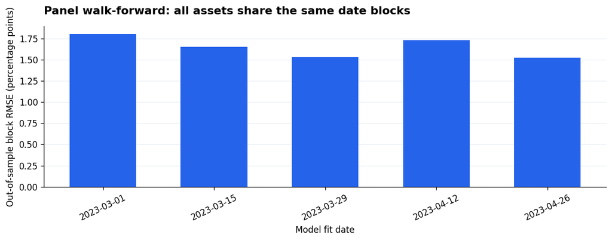

```python
plt.figure(figsize=(10, 4))
plt.bar(np.arange(len(folds)), folds['RMSE'] * 100, color=BLUE, width=0.6)
plt.xticks(np.arange(len(folds)), folds['fit_time'].dt.strftime('%Y-%m-%d'), rotation=25)
plt.title('Panel walk-forward: all assets share the same date blocks')
plt.xlabel('Model fit date')
plt.ylabel('Out-of-sample block RMSE (percentage points)')
plt.tight_layout()
plt.show()
```

**怎么看：** 审计表先核对 last_train_label_end 早于 fit_time。各块预测来自当时可训练的模型；下一块可以加入此时已经实现的旧标签，这与真实在线更新一致。

**换数据时注意：** 滚动过程是预先固定的评估方案；看完整段结果后再改模型，整段就成为开发集，需要另留新的测试期。标签是2期重叠收益，不能把预测表中的 target 逐行复合成交易净值；交易执行另按03册建账。

## M13 · 验证集 Permutation Importance：哪些特征影响预测误差

**先看输入 DataFrame：** 以下是实际参与此例计算的数据预览。

```python
rng = np.random.RandomState(113)
n = 200
momentum = rng.normal(size=n)
flow = rng.normal(size=n)
df = pd.DataFrame({
    'date': pd.bdate_range('2023-01-02', periods=n),
    'momentum': momentum, 'flow': flow, 'noise_feature': rng.normal(size=n),
    'return_oc': 0.006 * momentum + 0.004 * np.tanh(flow) + rng.normal(0, 0.006, n),
})
print('输入共', len(df), '行；先看前8行')
display(df.head(8))
```

```
输入共 200 行；先看前8行
```

|  | date | momentum | flow | noise_feature | return_oc |
| --- | --- | --- | --- | --- | --- |
| 0 | 2023-01-02 | -0.149990 | -0.218773 | -0.134373 | 0.000233 |
| 1 | 2023-01-03 | 0.932751 | -1.105895 | 1.728608 | -0.005791 |
| 2 | 2023-01-04 | 0.209199 | -0.159024 | 0.070172 | -0.009217 |
| 3 | 2023-01-05 | -1.026783 | 0.817710 | -0.432065 | -0.004873 |
| 4 | 2023-01-06 | -0.226629 | 0.387244 | -0.295343 | -0.002079 |
| 5 | 2023-01-09 | 1.189292 | -0.782956 | 0.405015 | 0.006143 |
| 6 | 2023-01-10 | 1.079335 | -0.539706 | -0.770073 | -0.008645 |
| 7 | 2023-01-11 | 1.145230 | -0.076350 | 1.103653 | 0.025701 |

**场景 / 要做什么：**

**场景：** 想解释模型在未参与拟合的数据上依赖哪些特征。三列数值特征假定盘前可用；`return_oc` 是当天收盘后才能知道的开盘至收盘收益。

**要做什么：** 先用前60%训练随机森林，随后20%验证；在验证集打乱每个特征，计算 MAE 增加多少。最后20%暂不读取收益，保留给后续真正最终评估。

**示例代码：** 明确选择特征，先切分再拟合，最后展示结果。

```python
from sklearn.ensemble import RandomForestRegressor
from sklearn.inspection import permutation_importance
from sklearn.metrics import mean_absolute_error

data = df.copy()
data['date'] = pd.to_datetime(data['date'])
data = data.sort_values('date').reset_index(drop=True)
features = ['momentum', 'flow', 'noise_feature']
assert data['date'].is_unique and data['date'].notna().all()
cut1, cut2 = int(len(data) * 0.6), int(len(data) * 0.8)
train, valid = data.iloc[:cut1], data.iloc[cut1:cut2]
reserved_test = data.iloc[cut2:]
assert np.isfinite(data.iloc[:cut2][features + ['return_oc']]).all().all()
model = RandomForestRegressor(n_estimators=100, max_depth=4, min_samples_leaf=8,
                              random_state=13, n_jobs=1)
model.fit(train[features], train['return_oc'])
validation_mae = mean_absolute_error(valid['return_oc'], model.predict(valid[features]))
permuted = permutation_importance(model, valid[features], valid['return_oc'],
                                 scoring='neg_mean_absolute_error', n_repeats=15,
                                 random_state=13, n_jobs=1)
importance = pd.DataFrame({
    'feature': features, 'MAE_increase': permuted.importances_mean,
    'repeat_std': permuted.importances_std,
}).sort_values('MAE_increase')
display(pd.DataFrame({'validation_MAE': [validation_mae], 'untouched_test_rows': [len(reserved_test)]}))
display(importance.round(6))
```

|  | validation_MAE | untouched_test_rows |
| --- | --- | --- |
| 0 | 0.005264 | 40 |

|  | feature | MAE_increase | repeat_std |
| --- | --- | --- | --- |
| 2 | noise_feature | -0.000052 | 0.000059 |
| 1 | flow | 0.000304 | 0.000311 |
| 0 | momentum | 0.003875 | 0.000665 |

**可视化：** 使用刚刚计算出的指标和预测。

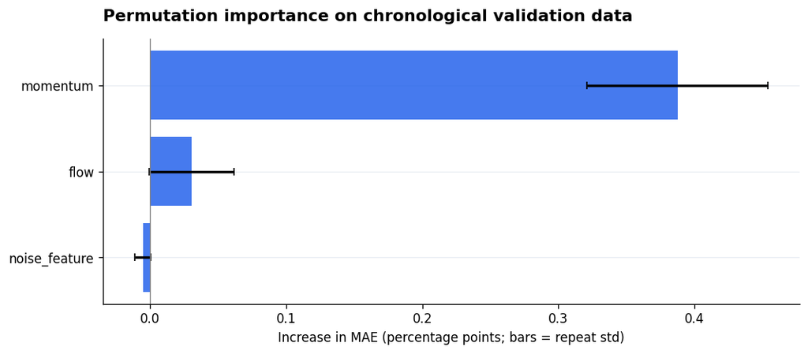

```python
plt.figure(figsize=(9, 4))
plt.barh(importance['feature'], importance['MAE_increase'] * 100,
         xerr=importance['repeat_std'] * 100, color=BLUE, alpha=0.85, capsize=3)
plt.axvline(0, color='grey', linewidth=0.8)
plt.title('Permutation importance on chronological validation data')
plt.xlabel('Increase in MAE (percentage points; bars = repeat std)')
plt.tight_layout()
plt.show()
```

**怎么看：** 条形越靠右，打乱这个特征后验证误差增幅越大。误差棒是重复打乱之间的标准差，不是统计置信区间。负值表示该次打乱反而改善误差，不能解释成稳定负因果作用。

**换数据时注意：** 只说明这个模型、这段验证数据中的预测依赖，不证明因果或交易价值。相关特征会相互替代；逐行打乱也会破坏时间结构，强自相关数据可改用保持块内结构的置换。按此结果选特征后，仍要用保留测试集做最终评估。

## M14 · 回归诊断：残差、Rank IC 与基准误差

**先看输入 DataFrame：** 以下是实际参与此例计算的数据预览。

```python
rng = np.random.RandomState(114)
n = 180
momentum, flow = rng.normal(size=n), rng.normal(size=n)
df = pd.DataFrame({
    'date': pd.bdate_range('2023-01-02', periods=n), 'momentum': momentum, 'flow': flow,
    'return_oc': 0.006 * momentum + 0.004 * flow ** 2 + rng.normal(0, 0.008, n),
})
print('输入共', len(df), '行；先看前8行')
display(df.head(8))
```

```
输入共 180 行；先看前8行
```

|  | date | momentum | flow | return_oc |
| --- | --- | --- | --- | --- |
| 0 | 2023-01-02 | -0.021762 | -0.736481 | 0.006660 |
| 1 | 2023-01-03 | 0.799883 | -1.258595 | 0.022227 |
| 2 | 2023-01-04 | -0.661443 | -0.001206 | -0.009329 |
| 3 | 2023-01-05 | 1.270890 | -1.335805 | 0.011496 |
| 4 | 2023-01-06 | 0.065540 | -0.447247 | 0.005616 |
| 5 | 2023-01-09 | -1.108123 | 2.024530 | -0.006265 |
| 6 | 2023-01-10 | -0.893253 | 0.775532 | -0.011331 |
| 7 | 2023-01-11 | 0.680416 | -2.304181 | 0.016590 |

**场景 / 要做什么：**

**场景：** 模型已经生成最终时间测试集的预测，要检查预测误差是否偏向一侧、预测与实际是否有排序关系。输入特征盘前可用，目标是同日开盘至收盘收益。

**要做什么：** 使用预先指定的 Ridge 模型，输出 MAE、RMSE、R²、平均残差及整个单资产测试期间的 Rank IC，并与训练均值预测对比。残差定义为实际减预测。

**示例代码：** 明确选择特征，先切分再拟合，最后展示结果。

```python
from sklearn.pipeline import make_pipeline
from sklearn.preprocessing import StandardScaler
from sklearn.linear_model import Ridge
from sklearn.metrics import mean_absolute_error, mean_squared_error, r2_score

data = df.copy()
data['date'] = pd.to_datetime(data['date'])
data = data.sort_values('date').reset_index(drop=True)
features = ['momentum', 'flow']
assert data['date'].notna().all() and data['date'].is_unique
assert np.isfinite(data[features + ['return_oc']]).all().all()
cut = int(len(data) * 0.7)
train, test = data.iloc[:cut], data.iloc[cut:].copy()
model = make_pipeline(StandardScaler(), Ridge(alpha=10))
model.fit(train[features], train['return_oc'])
test['prediction'] = model.predict(test[features])
test['residual'] = test['return_oc'] - test['prediction']
baseline = np.full(len(test), train['return_oc'].mean())
rank_ic = test['prediction'].corr(test['return_oc'], method='spearman') if test['prediction'].nunique() > 1 and test['return_oc'].nunique() > 1 else np.nan
metrics = pd.DataFrame({
    'MAE': [mean_absolute_error(test['return_oc'], test['prediction']), mean_absolute_error(test['return_oc'], baseline)],
    'RMSE': [np.sqrt(mean_squared_error(test['return_oc'], test['prediction'])), np.sqrt(mean_squared_error(test['return_oc'], baseline))],
    'R2': [r2_score(test['return_oc'], pred) if test['return_oc'].nunique() > 1 else np.nan
           for pred in [test['prediction'], baseline]],
}, index=['Ridge', 'Training mean'])
display(metrics.round(5))
display(pd.DataFrame({'mean_residual': [test['residual'].mean()], 'time_series_rank_IC': [rank_ic]}))
display(test[['date', 'return_oc', 'prediction', 'residual']].head(8).round(5))
```

|  | MAE | RMSE | R2 |
| --- | --- | --- | --- |
| Ridge | 0.00783 | 0.01007 | 0.29395 |
| Training mean | 0.00956 | 0.01202 | -0.00499 |

|  | mean_residual | time_series_rank_IC |
| --- | --- | --- |
| 0 | -0.001994 | 0.577778 |

|  | date | return_oc | prediction | residual |
| --- | --- | --- | --- | --- |
| 125 | 2023-06-26 | 0.02341 | -0.00744 | 0.03085 |
| 126 | 2023-06-27 | -0.00726 | 0.00865 | -0.01591 |
| 127 | 2023-06-28 | 0.02081 | 0.01008 | 0.01073 |
| 128 | 2023-06-29 | 0.01438 | 0.01545 | -0.00107 |
| 129 | 2023-06-30 | 0.00895 | 0.00873 | 0.00022 |
| 130 | 2023-07-03 | 0.00963 | 0.00656 | 0.00307 |
| 131 | 2023-07-04 | -0.01650 | 0.00225 | -0.01875 |
| 132 | 2023-07-05 | -0.02205 | -0.00753 | -0.01453 |

**可视化：** 使用刚刚计算出的指标和预测。

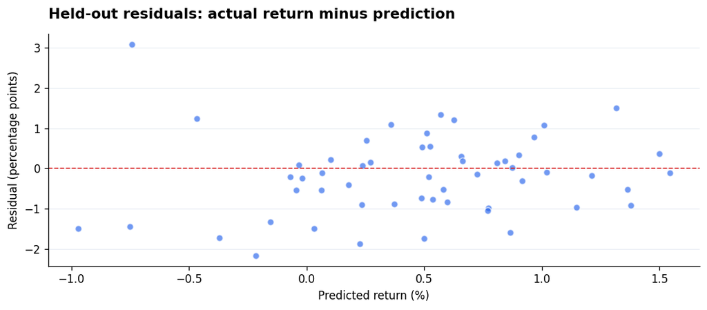

```python
plt.figure(figsize=(9, 4))
plt.scatter(test['prediction'] * 100, test['residual'] * 100, color=BLUE, alpha=0.65, edgecolors='white')
plt.axhline(0, color=RED, linestyle='--', linewidth=1)
plt.title('Held-out residuals: actual return minus prediction')
plt.xlabel('Predicted return (%)')
plt.ylabel('Residual (percentage points)')
plt.tight_layout()
plt.show()
```

**怎么看：** 残差系统偏正/负可能反映偏差；散点呈曲线可能是遗漏非线性。Rank IC 是本例单资产跨时间的 Spearman 相关，不是每天多资产的横截面 IC。

**换数据时注意：** 相关性不等于可交易收益，R²也可能为负；这里没有显著性检验。若看这张最终测试图后再修改特征或模型，该区间就成为开发资料，需新的未见区间重新验证。

## M15 · PCA 降维：只用训练期拟合，再投影未来数据

**先看输入 DataFrame：** 以下是实际参与此例计算的数据预览。

```python
rng = np.random.RandomState(115)
n = 160
factor_1, factor_2 = rng.normal(size=n), rng.normal(size=n)
df = pd.DataFrame({
    'date': pd.bdate_range('2023-01-02', periods=n),
    'feature_a': factor_1 + rng.normal(0, 0.2, n),
    'feature_b': 2 * factor_1 + rng.normal(0, 0.3, n),
    'feature_c': factor_2 + rng.normal(0, 0.2, n),
    'feature_d': factor_1 - factor_2 + rng.normal(0, 0.3, n),
})
print('输入共', len(df), '行；先看前8行')
display(df.head(8))
```

```
输入共 160 行；先看前8行
```

|  | date | feature_a | feature_b | feature_c | feature_d |
| --- | --- | --- | --- | --- | --- |
| 0 | 2023-01-02 | 0.875834 | 0.850167 | -0.363060 | 0.735750 |
| 1 | 2023-01-03 | -0.922109 | -2.279063 | -0.595486 | 0.076966 |
| 2 | 2023-01-04 | 1.360631 | 3.237719 | 2.164973 | -0.254362 |
| 3 | 2023-01-05 | -1.997418 | -3.424137 | -0.762973 | -1.229724 |
| 4 | 2023-01-06 | -1.122328 | -1.497008 | -1.218602 | 0.958149 |
| 5 | 2023-01-09 | 0.332896 | 1.182030 | 1.906524 | -1.600086 |
| 6 | 2023-01-10 | 1.857729 | 3.282901 | 0.768481 | 0.989123 |
| 7 | 2023-01-11 | 1.193737 | 2.732151 | -0.614556 | 2.225228 |

**场景 / 要做什么：**

**场景：** 多个数值特征高度相关，先想看主要变化方向或给后续模型提供低维输入。这里没有监督学习标签。

**要做什么：** 前75%日期拟合填充、标准化和两维 PCA，再把后25%投影到同一个坐标系，报告训练期解释方差比例和载荷。不能把未来数据一起拿去拟合 StandardScaler / PCA。

**示例代码：** 明确选择特征，先切分再拟合，最后展示结果。

```python
from sklearn.pipeline import make_pipeline
from sklearn.impute import SimpleImputer
from sklearn.preprocessing import StandardScaler
from sklearn.decomposition import PCA

data = df.copy()
data['date'] = pd.to_datetime(data['date'])
data = data.sort_values('date').reset_index(drop=True)
features = ['feature_a', 'feature_b', 'feature_c', 'feature_d']
assert data['date'].notna().all() and data['date'].is_unique
assert not np.isinf(data[features].to_numpy()).any()
cut = int(len(data) * 0.75)
train = data.iloc[:cut]
assert train[features].notna().any().all(), '训练期不能有整列缺失的特征'
pipeline = make_pipeline(SimpleImputer(strategy='median'), StandardScaler(), PCA(n_components=2))
pipeline.fit(train[features])
coordinates = pipeline.transform(data[features])  # transform不重新学习均值、尺度和方向。
projection = data[['date']].copy()
projection[['PC1', 'PC2']] = coordinates
projection['split'] = np.where(np.arange(len(data)) < cut, 'train', 'future')
pca = pipeline.named_steps['pca']
variance = pd.DataFrame({'explained_ratio': pca.explained_variance_ratio_}, index=['PC1', 'PC2'])
loadings = pd.DataFrame(pca.components_.T, index=features, columns=['PC1', 'PC2'])
display(variance.round(4))
display(loadings.round(4))
display(projection.head(8).round(4))
```

|  | explained_ratio |
| --- | --- |
| PC1 | 0.6372 |
| PC2 | 0.3442 |

|  | PC1 | PC2 |
| --- | --- | --- |
| feature_a | -0.5827 | -0.2890 |
| feature_b | -0.5737 | -0.3209 |
| feature_c | 0.1709 | -0.8142 |
| feature_d | -0.5497 | 0.3880 |

|  | date | PC1 | PC2 | split |
| --- | --- | --- | --- | --- |
| 0 | 2023-01-02 | -1.1531 | 0.2948 | train |
| 1 | 2023-01-03 | 0.9609 | 1.2831 | train |
| 2 | 2023-01-04 | -1.2926 | -2.4857 | train |
| 3 | 2023-01-05 | 2.3782 | 1.5203 | train |
| 4 | 2023-01-06 | 0.3882 | 1.9504 | train |
| 5 | 2023-01-09 | 0.3619 | -2.0544 | train |
| 6 | 2023-01-10 | -2.3081 | -1.1798 | train |
| 7 | 2023-01-11 | -2.5103 | 0.5251 | train |

**可视化：** 使用刚刚计算出的指标和预测。

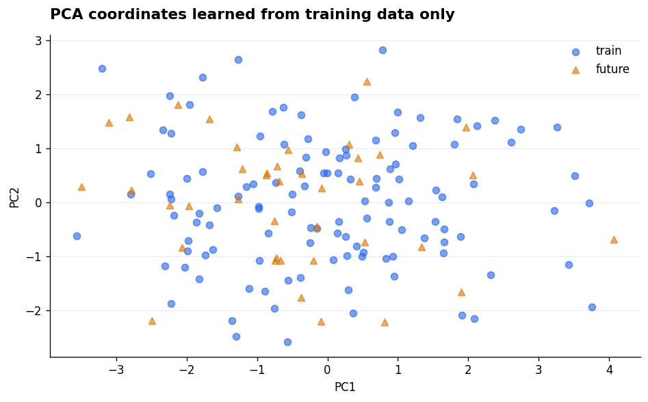

```python
plt.figure(figsize=(8, 5))
for group, color, marker in [('train', BLUE, 'o'), ('future', ORANGE, '^')]:
    points = projection.loc[projection['split'].eq(group)]
    plt.scatter(points['PC1'], points['PC2'], color=color, marker=marker, alpha=0.6, label=group)
plt.title('PCA coordinates learned from training data only')
plt.xlabel('PC1')
plt.ylabel('PC2')
plt.legend()
plt.tight_layout()
plt.show()
```

**怎么看：** 投影用于观察训练期与未来期的分布是否相似。载荷表示标准化特征如何组成主成分，方差比例来自训练数据。

**换数据时注意：** PCA 保留的是特征方差，不是预测收益的能力；解释方差高也不保证模型效果好。若将 PCA 用于监督模型，应该放进同一 Pipeline，每个时间 fold 内重新拟合；主成分整体符号可以翻转。

## M16 · 模型预测 → 仓位 → 样本外日内回测

**先看输入 DataFrame：** 以下是实际参与此例计算的数据预览。

```python
rng = np.random.RandomState(116)
n = 210
momentum, flow = rng.normal(size=n), rng.normal(size=n)
open_price = 100 * np.exp(np.cumsum(rng.normal(0, 0.002, n)))
day_return = 0.003 * momentum + 0.002 * flow + rng.normal(0, 0.01, n)
df = pd.DataFrame({
    'date': pd.bdate_range('2023-01-02', periods=n),
    'momentum': momentum, 'flow': flow,
    'open': open_price, 'close': open_price * (1 + day_return),
})
print('输入共', len(df), '行；先看前8行')
display(df.head(8))
```

```
输入共 210 行；先看前8行
```

|  | date | momentum | flow | open | close |
| --- | --- | --- | --- | --- | --- |
| 0 | 2023-01-02 | -1.492299 | 0.303057 | 99.613839 | 98.785088 |
| 1 | 2023-01-03 | -1.231295 | -0.280379 | 99.532132 | 99.359146 |
| 2 | 2023-01-04 | -0.028144 | -1.401049 | 99.581527 | 100.967433 |
| 3 | 2023-01-05 | -0.586060 | -0.348715 | 99.629364 | 100.097774 |
| 4 | 2023-01-06 | 0.074709 | 0.512969 | 99.805997 | 99.179484 |
| 5 | 2023-01-09 | -0.053600 | -1.662248 | 99.899384 | 98.723980 |
| 6 | 2023-01-10 | 1.508410 | -0.030540 | 100.246870 | 100.041215 |
| 7 | 2023-01-11 | -0.234901 | 0.024991 | 100.238246 | 100.960465 |

**场景 / 要做什么：**

**场景：** 将监督模型预测接到03册的回测。`momentum / flow` 假定在当天开盘前已经可用，`open / close` 是当天可成交与估值价格；模型预测开盘至收盘收益。

**要做什么：** 按时间60%训练、20%验证、20%测试。训练 Ridge，验证集选择不交易区间的阈值；模型和阈值均锁定后，每天开盘按预测决定 +50% / −50% / 0 仓位，收盘全部平仓，扣两边实际名义成交金额的费用。

**示例代码：** 明确选择特征，先切分再拟合，最后展示结果。

```python
from sklearn.pipeline import make_pipeline
from sklearn.preprocessing import StandardScaler
from sklearn.linear_model import Ridge
from sklearn.metrics import mean_squared_error

data = df.copy()
data['date'] = pd.to_datetime(data['date'])
data = data.sort_values('date').reset_index(drop=True)
features = ['momentum', 'flow']
assert data['date'].notna().all() and data['date'].is_unique
assert np.isfinite(data[features + ['open', 'close']]).all().all()
assert (data[['open', 'close']] > 0).all().all()
data['return_oc'] = data['close'] / data['open'] - 1
cut1, cut2 = int(len(data) * 0.6), int(len(data) * 0.8)
train, valid, test = data.iloc[:cut1], data.iloc[cut1:cut2], data.iloc[cut2:].copy()
model = make_pipeline(StandardScaler(), Ridge(alpha=10))
model.fit(train[features], train['return_oc'])
validation_prediction = model.predict(valid[features])
fee_rate, max_weight = 2 / 10000, 0.5
thresholds = [0.0, 0.001, 0.002, 0.003]
rows = []
for threshold in thresholds:
    weight = np.sign(validation_prediction) * (np.abs(validation_prediction) > threshold) * max_weight
    cost = fee_rate * np.abs(weight) * (2 + valid['return_oc'])
    net = weight * valid['return_oc'] - cost
    assert (net > -1).all()
    rows.append([threshold, (1 + net).prod() - 1])
selection = pd.DataFrame(rows, columns=['threshold', 'validation_net_return'])
best_threshold = selection.loc[selection['validation_net_return'].idxmax(), 'threshold']
test['prediction'] = model.predict(test[features])  # 不在test重新训练或重新挑阈值。
test['position'] = np.sign(test['prediction']) * test['prediction'].abs().gt(best_threshold) * max_weight
test['cost'] = fee_rate * test['position'].abs() * (2 + test['return_oc'])
test['strategy_return'] = test['position'] * test['return_oc'] - test['cost']
assert test['strategy_return'].gt(-1).all()
test['nav'] = (1 + test['strategy_return']).cumprod()
test['drawdown'] = test['nav'] / test['nav'].cummax().clip(lower=1) - 1
display(selection.round(5))
display(test[['date', 'prediction', 'position', 'return_oc', 'cost', 'strategy_return', 'nav']].head(8).round(5))
display(pd.DataFrame({'test_RMSE': [np.sqrt(mean_squared_error(test['return_oc'], test['prediction']))],
                      'net_return': [test['nav'].iloc[-1] - 1], 'max_drawdown': [test['drawdown'].min()],
                      'active_days': [test['position'].ne(0).sum()], 'locked_threshold': [best_threshold]}))
```

|  | threshold | validation_net_return |
| --- | --- | --- |
| 0 | 0.000 | 0.07261 |
| 1 | 0.001 | 0.06672 |
| 2 | 0.002 | 0.05880 |
| 3 | 0.003 | 0.04551 |

|  | date | prediction | position | return_oc | cost | strategy_return | nav |
| --- | --- | --- | --- | --- | --- | --- | --- |
| 168 | 2023-08-24 | -0.00174 | -0.5 | 0.00362 | 0.0002 | -0.00201 | 0.99799 |
| 169 | 2023-08-25 | 0.00494 | 0.5 | 0.00210 | 0.0002 | 0.00085 | 0.99884 |
| 170 | 2023-08-28 | -0.00446 | -0.5 | -0.00223 | 0.0002 | 0.00092 | 0.99975 |
| 171 | 2023-08-29 | -0.00553 | -0.5 | -0.00475 | 0.0002 | 0.00217 | 1.00193 |
| 172 | 2023-08-30 | -0.00099 | -0.5 | 0.00372 | 0.0002 | -0.00206 | 0.99986 |
| 173 | 2023-08-31 | 0.00008 | 0.5 | -0.01411 | 0.0002 | -0.00725 | 0.99261 |
| 174 | 2023-09-01 | 0.00346 | 0.5 | 0.01909 | 0.0002 | 0.00935 | 1.00189 |
| 175 | 2023-09-04 | 0.00040 | 0.5 | -0.01204 | 0.0002 | -0.00622 | 0.99565 |

|  | test_RMSE | net_return | max_drawdown | active_days | locked_threshold |
| --- | --- | --- | --- | --- | --- |
| 0 | 0.010472 | 0.036654 | -0.018607 | 42 | 0.0 |

**可视化：** 使用刚刚计算出的指标和预测。

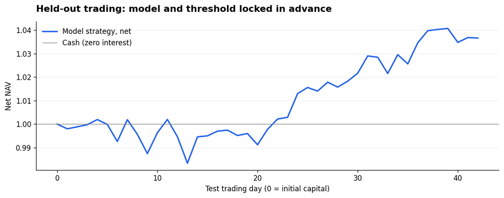

```python
plt.figure(figsize=(10, 4))
plt.plot(np.arange(len(test) + 1), np.r_[1, test['nav'].to_numpy()], color=BLUE, label='Model strategy, net')
plt.axhline(1, color='grey', linewidth=0.8, label='Cash (zero interest)')
plt.title('Held-out trading: model and threshold locked in advance')
plt.xlabel('Test trading day (0 = initial capital)')
plt.ylabel('Net NAV')
plt.legend()
plt.tight_layout()
plt.show()
```

**怎么看：** 预测误差与净收益分别报告。当天盘前预测决定当天开仓，因此直接乘同日 return_oc，不再 shift；若特征只能收盘后知道，就必须改变成交时点与标签，不能只照抄此公式。

**换数据时注意：** 这是合成可预测关系演示，不是发现了真实 alpha；忽略滑点、借券、容量与保证金。fee_rate是单边，cost包括入场和按收盘市值退出。模型只用训练集拟合，验证后未重新拟合，阈值与所用模型保持配套。测试收益可命名为 strategy_return 后接03册 B15–B17。

## 现场换数据时，优先改这几处

| 要改什么 | 操作 |
| --- | --- |
| 特征列 | 修改 `features` 或 `numeric / categorical`，只放预测时已知的列 |
| 目标 | 选择连续收益/金额用回归，二元事件用分类；不要把未知标签填0 |
| 日期与资产 | 日期先转 datetime 并排序；单序列日期唯一，面板 `(date, asset)` 唯一 |
| 时间切分 | 把比例边界改成研究需要的真实日期；同日资产成块，跨期标签按实际到期时间 purge |
| 预处理 | `.fit()` 只对 train；测试只能 `.transform()` 或 `.predict()`；CV 时 Pipeline 在每折里拟合 |
| 类别与常量 | 检查训练是否只有一个类；单类测试不报告ROC-AUC，常量回归目标不解释R² |
| 候选参数 | 先在训练/验证中决定；不要用最终 test 比较一堆方案再把最好者当无偏结果 |
| 样本量 | 小数据不能支持深树与大范围搜索；同时报告样本数、基准误差和分段表现 |
| 外部数据 | 检查真正发布时间、历史修订、存活偏差和当时可交易范围 |

**一眼看懂 sklearn 常用动作：** `fit(X_train, y_train)` 学习；`predict(X_test)` 输出值/类别；`predict_proba(X_test)[:, 1]` 输出二分类正类概率；`Pipeline` 把预处理和模型绑定；`GridSearchCV` 只在传入的开发数据内部比较候选。

**读图怎么选：** 回归用实际值对预测值散点、残差图；分类用混淆矩阵、PR/ROC；树复杂度用训练/验证误差曲线；模型解释用验证集置换重要性；交易效果单独看样本外净值与回撤。 不能因为两个案例的合成数据不同，却直接用它们的 RMSE 判定哪个模型更好。正式比较需要同一目标、相同切分与相同基准。

**保存图：** 在对应 `plt.show()` 前加入 `plt.savefig('ml_chart.png', dpi=180, bbox_inches='tight')`。

## API 对照资料

- [scikit-learn：避免预处理与数据泄漏错误](https://scikit-learn.org/1.3/common_pitfalls.html)
- [TimeSeriesSplit 的 gap 和时间边界](https://scikit-learn.org/1.3/modules/generated/sklearn.model_selection.TimeSeriesSplit.html)
- [置换重要性的解释与限制](https://scikit-learn.org/1.3/modules/permutation_importance.html)
- [HistGradientBoostingRegressor](https://scikit-learn.org/1.3/modules/generated/sklearn.ensemble.HistGradientBoostingRegressor.html)
- [XGBoost 2.0 sklearn API 和 early stopping](https://xgboost.readthedocs.io/en/release_2.0.0/python/python_api.html)

返回回测手册 · 基础可视化